# **TAREA FINAL**

- Raúl Arellano
- María Sánchez Yuste
- Sofía Garcia-Baquero

Airbnb es una compañía que ofrece una plataforma digital dedicada a la oferta de alojamientos a particulares y turísticos mediante anfitriones, que ponen sus apartamentos en arrendamiento.

Con esta práctica vamos a predecir los precios de los alojamientos de Vancouver. En primera instancia, trataremos los datos realizando un preprocesamiento para seleccionar los más relevantes bien tratados y poder llevar a cabo una serie de modelos. Por último, comprobaremos nuestra predicción sobre un dataset de validación para acercarnos lo máximo posible a un problema real de negocio.

## Librerías

Lo primero de todo, abrimos las librerias que vamos a necesitar a lo largo de la práctica para trataiento de datos, creacion de modelos y de redes neuronales.

```python
!pip install category_encoders
import geopy
import folium
import datetime
import requests
import statistics
import numpy as np
import pandas as pd
import seaborn as sns
import multiprocessing
import statsmodels.api as sm
from matplotlib import pyplot
import category_encoders as ce
import matplotlib.pyplot as plt
from folium.plugins import HeatMap
from matplotlib import pyplot as plt
from sklearn.impute import KNNImputer
from sklearn.decomposition import PCA
from pandas_profiling import ProfileReport
from sklearn.metrics import mean_squared_error
from sklearn.preprocessing import LabelEncoder
from geopy.extra.rate_limiter import RateLimiter
from sklearn.preprocessing import StandardScaler
from sklearn.model_selection import GridSearchCV
from sklearn.model_selection import ParameterGrid
from sklearn.model_selection import RepeatedKFold
from sklearn.ensemble import RandomForestRegressor
from sklearn.linear_model import LogisticRegression
from sklearn.model_selection import train_test_split
from sklearn.ensemble import GradientBoostingRegressor
from sklearn.model_selection import RandomizedSearchCV
from sklearn.metrics import mean_squared_error, r2_score, mean_absolute_error
from sklearn.metrics import average_precision_score, roc_curve, auc, recall_score, precision_score, confusion_matrix

pd.set_option("display.max_columns", 1000)
```

```
     |████████████████████████████████| 69 kB 1.9 MB/s
```

## Funciones necesarias para la práctica

A continuacion, creamos una serie de funciones que nos serán de ayuda a lo largo de la práctica para vcer la distribucion de las variables categóricas:

- **dame_variables_categoricas()**: Funcion para hallar con facilidad las variables categoricas del data set y poderlas tratar en conjunto
- **distribucion_categorica()**: Funcion para hallar la distribucion de las variables categóricas y asi ver el tipo de encoding que vamos a aplicar (OneHot, Target, Label...)

```python
def dame_variables_categoricas(dataset=None):
    if dataset is None:
        print(u'\nFaltan argumentos por pasar a la función')
        return 1
    lista_variables_categoricas = []
    other = []
    for i in dataset.columns:
        if (dataset[i].dtype!=float) & (dataset[i].dtype!=int):
            unicos = int(len(np.unique(dataset[i].dropna(axis=0, how='all'))))
            if unicos < 100:
                lista_variables_categoricas.append(i)
            else:
                other.append(i)

    return lista_variables_categoricas, other
```

```python
def distribucion_categorica(columna):
    df_rdo = pd.DataFrame({'number': [1] * len(data),
                           'index':columna}).groupby(['index']).sum().sort_values('number',ascending=False)
    df_rdo["percent"] = (df_rdo.number/df_rdo.number.sum()).mul(100)
    return df_rdo
```

## Dataset

A continuacion, cargamos los datos que hemos alojado en un repositorio de GitHub para facilitar el acceso a estos sin necesidad de cambiar la ubicacion en el PC

```python
data = pd.read_csv('https://raw.githubusercontent.com/raularellano/DataAirbnb/main/airbnb-listings-cleaned.csv')
data
```

|  | id | experiences_offered | host_id | host_name | host_since | host_location | host_response_time | host_response_rate | host_acceptance_rate | host_is_superhost | host_neighbourhood | host_listings_count | host_total_listings_count | host_has_profile_pic | host_identity_verified | street | neighbourhood | neighbourhood_cleansed | neighbourhood_group_cleansed | city | state | zipcode | market | smart_location | country_code | country | latitude | longitude | is_location_exact | … |
| --- | --- | --- | --- | --- | --- | --- | --- | --- | --- | --- | --- | --- | --- | --- | --- | --- | --- | --- | --- | --- | --- | --- | --- | --- | --- | --- | --- | --- | --- | --- |
| 0 | 10080 | none | 30899 | Rami | 2009-08-10 | Vancouver, British Columbia, Canada | within a few hours | 85% | NaN | f | Coal Harbour | 31.0 | 31.0 | t | t | Vancouver, BC, Canada | Coal Harbour | Downtown | NaN | Vancouver | BC | V6E 2P4 | Vancouver | Vancouver, Canada | CA | Canada | 49.287716 | -123.121103 | t | … |
| 1 | 11400 | none | 42305 | Jaynne | 2009-09-30 | Vancouver, British Columbia, Canada | NaN | NaN | NaN | f | Riley Park | 1.0 | 1.0 | t | t | Vancouver, BC, Canada | Riley Park | Riley Park | NaN | Vancouver | BC | V5Y | Vancouver | Vancouver, Canada | CA | Canada | 49.253756 | -123.112659 | t | … |
| 2 | 13188 | none | 51466 | Family Guns | 2009-11-04 | Vancouver, British Columbia, Canada | within an hour | 100% | NaN | t | Riley Park | 1.0 | 1.0 | t | t | Vancouver, BC, Canada | Riley Park | Riley Park | NaN | Vancouver | BC | V5Y | Vancouver | Vancouver, Canada | CA | Canada | 49.245770 | -123.105158 | t | … |
| 3 | 13357 | none | 52118 | Liliana | 2009-11-07 | Vancouver, British Columbia, Canada | within an hour | 100% | NaN | f | Chinatown | 4.0 | 4.0 | t | t | Vancouver, BC, Canada | Chinatown | Downtown Eastside | NaN | Vancouver | BC | V6B | Vancouver | Vancouver, Canada | CA | Canada | 49.279548 | -123.105457 | t | … |
| 4 | 13358 | none | 52116 | Lynn | 2009-11-07 | Vancouver, British Columbia, Canada | NaN | NaN | NaN | f | Downtown Vancouver | 1.0 | 1.0 | t | f | Vancouver, BC, Canada | Downtown Vancouver | West End | NaN | Vancouver | BC | V6Z 2S1 | Vancouver | Vancouver, Canada | CA | Canada | 49.282090 | -123.125150 | t | … |
| ... | ... | ... | ... | ... | ... | ... | ... | ... | ... | ... | ... | ... | ... | ... | ... | ... | ... | ... | ... | ... | ... | ... | ... | ... | ... | ... | ... | ... | ... | … |
| 4832 | 32135798 | none | 125368592 | James | 2017-04-11 | CA | within an hour | 100% | NaN | f | Downtown Vancouver | 4.0 | 4.0 | t | f | Vancouver, BC, Canada | Downtown Vancouver | Downtown | NaN | Vancouver | BC | V6B 3C1 | Vancouver | Vancouver, Canada | CA | Canada | 49.278126 | -123.119473 | t | … |
| 4833 | 32151243 | none | 241187818 | Cheung | 2019-02-05 | CA | NaN | NaN | NaN | f | Downtown Vancouver | 1.0 | 1.0 | t | f | Burnaby, BC, Canada | Downtown Vancouver | Downtown | NaN | Burnaby | BC | V5H 4L3 | Vancouver | Burnaby, Canada | CA | Canada | 49.278575 | -123.128176 | t | … |
| 4834 | 32152929 | none | 48291360 | Craig | 2015-11-05 | US | within an hour | 100% | NaN | f | Marpole | 3.0 | 3.0 | t | t | Vancouver, BC, Canada | Marpole | Marpole | NaN | Vancouver | BC | V6P 3X9 | Vancouver | Vancouver, Canada | CA | Canada | 49.212408 | -123.128458 | f | … |
| 4835 | 32160848 | none | 216510476 | Forough | 2018-09-21 | US | NaN | NaN | NaN | f | Yaletown | 1.0 | 1.0 | t | f | Vancouver, BC, Canada | Yaletown | Downtown | NaN | Vancouver | BC | V6B 1J7 | Vancouver | Vancouver, Canada | CA | Canada | 49.274608 | -123.118991 | t | … |
| 4836 | 32164701 | none | 30236899 | Mark | 2015-03-29 | Vancouver, British Columbia, Canada | NaN | NaN | NaN | f | Riley Park | 1.0 | 1.0 | t | f | Vancouver, BC, Canada | Riley Park | Riley Park | NaN | Vancouver | BC | V5V 2W6 | Vancouver | Vancouver, Canada | CA | Canada | 49.242407 | -123.096118 | t | … |

4837 rows × 82 columns

## Analisis descriptivo y tratamiento de datos

Primero realizaremos un ProfileReport con el fin de saber los valores en cada variable, saber mediante un primer analisis si los valores de estas son significativas para nuestro objetivo y ver cuantos datos missings hay. El report del Pandas Profiling se ha entregado adjunto.

```python
#ProfileReport(data)
```

### Eliminar variables segun Pandas Profiling

Despues de haber hecho el ProfileReport hemos eliminado las siguientes variables, al tener un numero muy elevado de datos missing y por tanto no aportar mucha significancia a nuestro objetivo, por repetir la misma informacion para todos los id o repetir informacion en otras variables.Para ver la distribucion de alguna de ellas, llamamos a la función que hemos creado antes

```python
data = data.set_index(["id"])
data = data.drop(['experiences_offered','host_acceptance_rate','neighbourhood_group_cleansed','country_code','country',  'has_availability', 'calendar_last_scraped', 'is_business_travel_ready',
                  'host_name', 'host_location','zipcode','smart_location', 'square_feet'], axis=1)
```

```python
plot_data = distribucion_categorica(data['cancellation_policy'])
plot_data
```

| index | number | percent |
| --- | --- | --- |
| strict_14_with_grace_period | 2590 | 53.545586 |
| moderate | 1356 | 28.033905 |
| flexible | 890 | 18.399835 |
| super_strict_30 | 1 | 0.020674 |

### Tratamiento previo de datos generales

A continuación, realizamos el tratamiento de datos de una serie de vaariables categoricas ajustandonos a su distribucion y tomando las decisiones más optimas posibles para facilitar nuestra prediccion mas delante:

- Hemos querido tratar primero las variables categoricas que presentaban **fechas** para poder eliminar el dia de estas ya que consideramos que no es significante (solo nos quedaremos con el mes y el año para saber las temporadas mas altas, ya que la diferencia entre una review el 2 de Junio o el 7 de Junio no es significativa, pero si entre Junio y Enero). Las variables de fecha son *host_since, first_review y last_review.*
- Eliminamos los pisos cuyo *market* no sean Vancouver para quedarnos solo con Canada, porque son solo 5 datos y nos compensa asumir la perdida de datos
- Sobre la variable *cancellation_policy* hemos agrupado super_strict_30 y strict_14_with_grace_period como un mismo datos (strict) y asi hacer mas facil su analisis, dividiendo simplemente en strict, flexible y moderate.
- En la variable *calendar_updated* hemos agrupado las actualizaciones de calendario, hemos seguido la misma logica que el anterior codigo y se ha hecho a fines de poder tener un analisis mas sencillo y visual

```python
data['host_since'] = pd.to_datetime(data['host_since'].values)
data['first_review'] = pd.to_datetime(data['first_review'].values)
data['last_review'] = pd.to_datetime(data['last_review'].values)
data['host_since'] = data['host_since'].apply(lambda x: x.strftime('%Y-%m') if(pd.notnull(x)) else x)
data['first_review'] = data['first_review'].apply(lambda x: x.strftime('%Y-%m') if(pd.notnull(x)) else x)
data['last_review'] = data['last_review'].apply(lambda x: x.strftime('%Y-%m') if(pd.notnull(x)) else x)

data["extra_people"] = data["extra_people"].apply(lambda x: float(x.replace("$", "")))

data.drop(data.loc[data['market']=='Portland'].index, inplace=True)
data.drop(data.loc[data['market']=='Munich'].index, inplace=True)

data['cancellation_policy'] = data['cancellation_policy'].apply(lambda id: {'flexible': 'flexible',
                                                                  'moderate': 'moderate',
                                                                  'super_strict_30': 'strict',
                                                                  'strict_14_with_grace_period': 'strict'}[str(id)])

distribucion_categorica(data['cancellation_policy'])
data = data[data.cancellation_policy.isin(['flexible','moderate','strict'])]

plot_data = distribucion_categorica(data['cancellation_policy'])
plot_data

data['calendar_updated'] = data['calendar_updated'].apply(lambda id: {'today': 'today',
                                                                      'yesterday':'yesterday',
                                                                      '10 months ago': '6-12 months ago',
                                                                      '5 days ago': '5 days ago',
                                                                      '4 weeks ago': '4 weeks ago',
                                                                      '5 weeks ago': '2 months ago',
                                                                      '2 months ago':'2 months ago',
                                                                      '5 months ago': '5 months ago',
                                                                      '3 months ago': '3 months ago',
                                                                      '6 weeks ago':'2 months ago',
                                                                      '2 weeks ago':'2 weeks ago',
                                                                      'a week ago' : 'a week ago',
                                                                      '3 weeks ago': '3 weeks ago',
                                                                      '16 months ago': '2 years ago',
                                                                      '4 days ago': '4 days ago',
                                                                      '3 days ago': '3 days ago',
                                                                      '2 days ago': '2 days ago',
                                                                      '4 months ago': '4 months ago',
                                                                      '6 months ago': '6-12 months ago',
                                                                      '7 weeks ago':'2 months ago',
                                                                      '9 months ago': '6-12 months ago',
                                                                      '11 months ago': '6-12 months ago',
                                                                      '25 months ago':'3 years ago',
                                                                      '7 months ago': '6-12 months ago',
                                                                      '1 week ago': '1 week ago',
                                                                      '32 months ago': '3 years ago',
                                                                      '6 days ago' : '6 days ago',
                                                                      '13 months ago': '2 years ago',
                                                                      '18 months ago': '2 years ago',
                                                                      '8 months ago': '6-12 months ago',
                                                                      '19 months ago': '2 years ago',
                                                                      '12 months ago': '6-12 months ago',
                                                                      '24 months ago': '2 years ago',
                                                                      '17 months ago': '2 years ago',
                                                                      '34 months ago': '3 years ago',
                                                                      '22 months ago':'2 years ago',
                                                                      '33 months ago':'3 years ago',
                                                                      '36 months ago':'3 years ago',
                                                                      '20 months ago':'2 years ago',
                                                                      '44 months ago':'4 years ago',
                                                                      '29 months ago': '3 years ago',
                                                                      '37 months ago':'4 years ago',
                                                                      '39 months ago':'4 years ago',
                                                                      '21 months ago': '2 years ago',
                                                                      '31 months ago': '3 years ago',
                                                                      '30 months ago': '3 years ago',
                                                                      '14 months ago': '2 years ago',
                                                                      '15 months ago': '2 years ago'}[str(id)])
```

### Fechas

A continuacion trataremos las tres variables de fechas, donde primero las hemos convertido en un tipo datatime para poder convertirlas despues en variables numericas y asi poder tratar sus datos missing y outliers.

#### Primera y ultima reseña

```python
data["last_review"] = pd.to_datetime(data["last_review"])
data["last_review"] = data["last_review"].astype(int)

data["first_review"] = pd.to_datetime(data["first_review"])
data["first_review"] = data["first_review"].astype(int)

data["last_review"] = data["last_review"].fillna(0)
data["first_review"] = data["first_review"].fillna(0)

data["last_review"] = data["last_review"]/(60*60*24*365)
data["first_review"] = data["last_review"]/(60*60*24*365)
```

#### Host since

Hemos realizado lo mismo que con las anteriores fechas y asi los datos esten en horas y tener unos valores mas sinplificados, además de tener la misma escala en estas tres variables

```python
data["host_since"] = pd.to_datetime(data["host_since"])
data["host_since"] = data["host_since"].astype(int)

data["host_since"] = data["host_since"]/(60*60*24*365)
```

### Precio semanal y mensual

Para ver la relación entre precio semanal y mensual respecto del precio del apartamento hemos establecido una regresión lineal para imputar los datos missing de estas variables

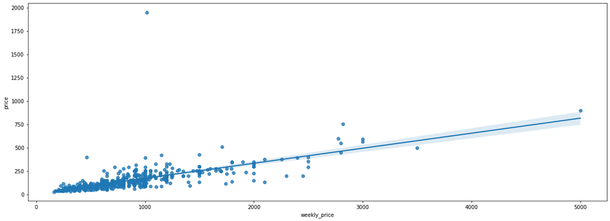

```python
%matplotlib inline
fig, ax = plt.subplots(figsize=(20,7))
sns.regplot(x="weekly_price", y="price", data=data)
```

```python
model = sm.OLS(data["weekly_price"], data['price'], missing='drop').fit()
print(model.summary())
```

```
                                 OLS Regression Results
=======================================================================================
Dep. Variable:           weekly_price   R-squared (uncentered):                   0.765
Model:                            OLS   Adj. R-squared (uncentered):              0.765
Method:                 Least Squares   F-statistic:                              1811.
Date:                Mon, 13 Jun 2022   Prob (F-statistic):                   6.79e-177
Time:                        19:58:05   Log-Likelihood:                         -4209.0
No. Observations:                 556   AIC:                                      8420.
Df Residuals:                     555   BIC:                                      8424.
Df Model:                           1
Covariance Type:            nonrobust
==============================================================================
                 coef    std err          t      P>|t|      [0.025      0.975]
------------------------------------------------------------------------------
price          4.4825      0.105     42.558      0.000       4.276       4.689
==============================================================================
Omnibus:                      968.315   Durbin-Watson:                   1.886
Prob(Omnibus):                  0.000   Jarque-Bera (JB):           887047.653
Skew:                         -10.565   Prob(JB):                         0.00
Kurtosis:                     197.534   Cond. No.                         1.00
==============================================================================

Warnings:
[1] Standard Errors assume that the covariance matrix of the errors is correctly specified.
```

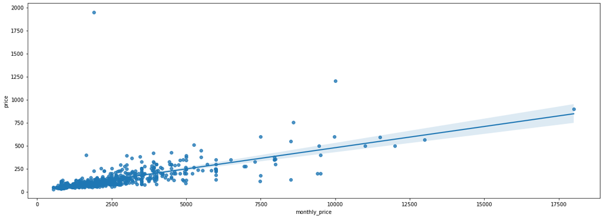

```python
%matplotlib inline
fig, ax = plt.subplots(figsize=(20,7))
sns.regplot(x="monthly_price", y="price", data=data)
```

```python
model = sm.OLS(data["monthly_price"], data['price'], missing='drop').fit()
print(model.summary())
```

```
                                 OLS Regression Results
=======================================================================================
Dep. Variable:          monthly_price   R-squared (uncentered):                   0.738
Model:                            OLS   Adj. R-squared (uncentered):              0.737
Method:                 Least Squares   F-statistic:                              1659.
Date:                Mon, 13 Jun 2022   Prob (F-statistic):                   1.48e-173
Time:                        19:58:05   Log-Likelihood:                         -5243.2
No. Observations:                 591   AIC:                                  1.049e+04
Df Residuals:                     590   BIC:                                  1.049e+04
Df Model:                           1
Covariance Type:            nonrobust
==============================================================================
                 coef    std err          t      P>|t|      [0.025      0.975]
------------------------------------------------------------------------------
price         14.6425      0.360     40.726      0.000      13.936      15.349
==============================================================================
Omnibus:                      903.094   Durbin-Watson:                   1.706
Prob(Omnibus):                  0.000   Jarque-Bera (JB):           521622.156
Skew:                          -8.240   Prob(JB):                         0.00
Kurtosis:                     147.607   Cond. No.                         1.00
==============================================================================

Warnings:
[1] Standard Errors assume that the covariance matrix of the errors is correctly specified.
```

Con un coeficiente de determinacion R2 de de entorno a 0.75, podemos aprovechar los datos conocidos de las variables precio para imputar el precio mensual de cada apartamento. Los outliers serán tratados más adelante.

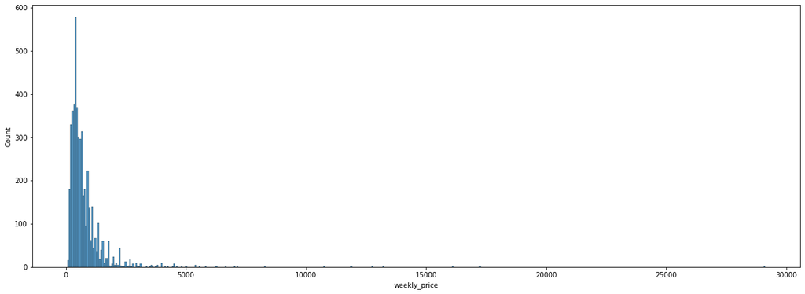

```python
data["weekly_price"] = data["weekly_price"].fillna(data["price"]*4.48)
fig, ax = plt.subplots(figsize=(20,7))
sns.histplot(data["weekly_price"])
```

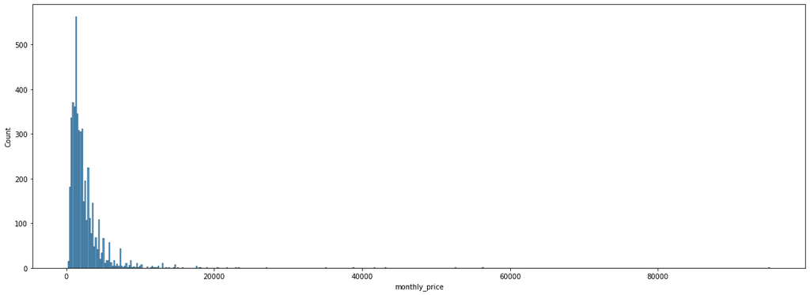

```python
data["monthly_price"] = data["monthly_price"].fillna(data["price"]*14.64)
fig, ax = plt.subplots(figsize=(20,7))
sns.histplot(data["monthly_price"])
```

Tras haber sustituido ambas variables, hemos querido grafiar sus respectivos histogrmas para ver si siguen la misma dustribucion que al principio de puede observar en el ProfileResport. Al comprobar que siguen la misma distirbucion hemos optado como esta opcion por la optima, aunque tambien contamos con que habremos metido algun tipo de ruido los datos debido a los decuentos aplicados al precio diario segun la duracion, pero al suponer que es minimo no hemos querido tratar mas la varibles.

### Outliers

Hemos eliminado los outliers de las variables numéricas que apriori parecen más significativas para predecir el precio de un apartamento:

Estos filtros se han aplicado teniendo en cuenta que es posible que en la introducción de nuevos individuos en el futuro, estos puedan tener valores un tanto superiores a lo que tienen los actuales, por lo que se han realizado cortes teniendo en cuenta margenes de error bastante amplios.

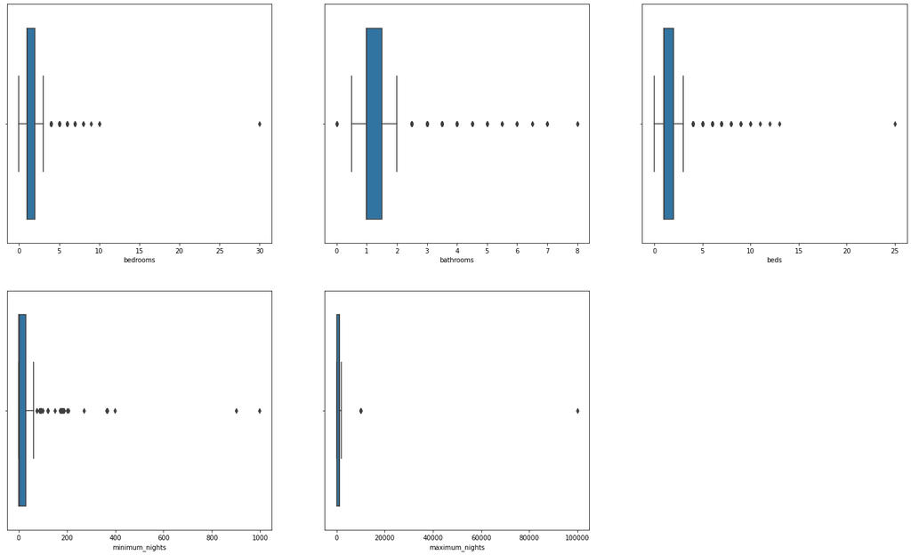

```python
plt.subplots(figsize=(25,15))
plt.subplot(231)
sns.boxplot(data['bedrooms'])
plt.subplot(232)
sns.boxplot(data['bathrooms'])
plt.subplot(233)
sns.boxplot(data['beds'])
plt.subplot(234)
sns.boxplot(data['minimum_nights'])
plt.subplot(235)
sns.boxplot(data['maximum_nights'])
```

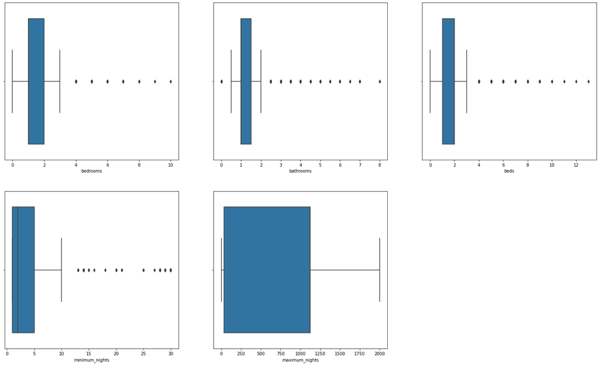

```python
data.drop(data.loc[data['bedrooms']>15].index, inplace=True)
data.drop(data.loc[data['beds']>15].index, inplace=True)
data.drop(data.loc[data['minimum_nights']>30].index, inplace=True)
data.drop(data.loc[data['maximum_nights']>2000].index, inplace=True)

plt.subplots(figsize=(25,15))
plt.subplot(231)
sns.boxplot(data['bedrooms'])
plt.subplot(232)
sns.boxplot(data['bathrooms'])
plt.subplot(233)
sns.boxplot(data['beds'])
plt.subplot(234)
sns.boxplot(data['minimum_nights'])
plt.subplot(235)
sns.boxplot(data['maximum_nights'])
```

### Mínimos y máximos días de estancia

Al no tener informacion sobre la descripcion de las siguientes variable, hemos realizado un PCA para ver lo que explica cada una y asi poder saber si se pueden sustituir por un factor conjunto (en caso de que aporten la misma informacion). Esto se hara para minizar el riesgo de tener varibles no controladas dentro de nuestro analisis.

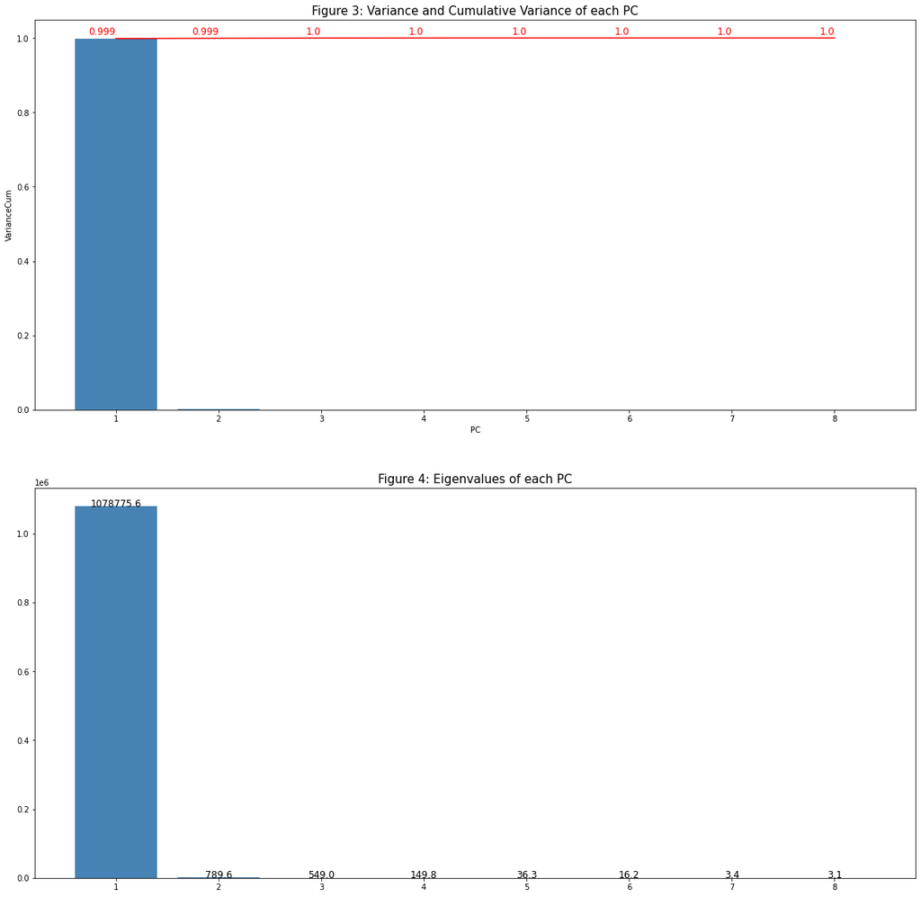

```python
data_pca_prueba = data[['maximum_nights','minimum_nights', 'minimum_minimum_nights', 'maximum_minimum_nights', 'minimum_maximum_nights', 'maximum_maximum_nights', 'minimum_nights_avg_ntm', 'maximum_nights_avg_ntm']]
data_pca_prueba.corr()

PCA = PCA()
pca_min_max = PCA.fit(data_pca_prueba.dropna())
summary30 = pd.DataFrame({'Variance' : pca_min_max.explained_variance_ratio_,
                          'VarianceCum' : pca_min_max.explained_variance_ratio_.cumsum(),
                          'Eigenvalue' : pca_min_max.explained_variance_,
                          'PC' : np.arange(1, len(pca_min_max.explained_variance_ratio_)+1)})

plt.figure(num = 3, figsize=(20,20))

plt.subplot(211)
plt.bar(data = summary30,
         height = 'Variance', x = 'PC', color="steelblue")
sns.lineplot(data = summary30,
         y = 'VarianceCum', x = 'PC', color="red")
for i, v in enumerate(round(summary30.VarianceCum,3)):
    plt.text(summary30.PC.tolist()[i], v+0.01, str(v), ha='right',
             fontsize=12, color = 'red')
plt.title('Figure 3: Variance and Cumulative Variance of each PC', size=15)

plt.subplot(212)
plt.figure(num = 3, figsize=(20,10))
plt.bar(data = summary30,
         height = 'Eigenvalue', x = 'PC', color="steelblue")
for i, v in enumerate(round(summary30.Eigenvalue,1)):
    plt.text(summary30.PC.tolist()[i], v+2, str(v), ha='center',
             fontsize=12, color = 'black')
plt.title('Figure 4: Eigenvalues of each PC', size=15)
plt.show()
```

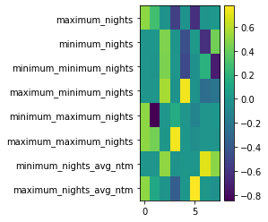

```python
data_min_max = data.loc[:, ['maximum_nights','minimum_nights','minimum_minimum_nights', 'maximum_minimum_nights', 'minimum_maximum_nights', 'maximum_maximum_nights', 'minimum_nights_avg_ntm', 'maximum_nights_avg_ntm']]

fig, ax = plt.subplots(nrows=1, ncols=1, figsize=(2, 4))
componentes = pca_min_max.components_
plt.imshow(componentes.T, cmap='viridis', aspect='auto')
plt.yticks(range(len(data_min_max.columns)), data_min_max.columns)
plt.xticks()
plt.grid(False)
plt.colorbar();
```

```python
pcs = pca_min_max.components_
normalized_pcs = list()

for eigen_vector in pcs:
    normalized_values = eigen_vector/eigen_vector.sum()
    normalized_pcs.append(normalized_values)

pc_w = normalized_pcs[0]
eigen_prtf1 = pd.DataFrame({'weights':pc_w.squeeze()} ,
                           index = data_min_max.columns.values.tolist()[0:418])
eigen_prtf1
```

|  | weights |
| --- | --- |
| maximum_nights | 0.249688 |
| minimum_nights | 0.000400 |
| minimum_minimum_nights | 0.000328 |
| maximum_minimum_nights | 0.000439 |
| minimum_maximum_nights | 0.249479 |
| maximum_maximum_nights | 0.249629 |
| minimum_nights_avg_ntm | 0.000394 |
| maximum_nights_avg_ntm | 0.249642 |

Como se puede ver tras el PCA las variables minimum_maximum_nights, maximum_maximum_nights y maximum_nights_avg_ntm explican lo mismo que la variable maximum_nights, por otro lado, vemos que las variables minimum_nights_avg_ntm, maximum_minimum_nights y minimum_minimum_nights explica lo mismo que minimum_night. Al estar muy correlacionadas y aportar la misma informacion hemos decidifo sustituir las variables por una solo que se llama factor de maximas noches, ya que las minimas estancias solo explican un 0,16% del total.

Hemos supuesto que la componente principal es el factor de maximo numero de noches de estanacia, por ello eliminaremos las siguientes variables y las sustituimos por la PC1.

```python
data = data.drop(["minimum_minimum_nights", "maximum_minimum_nights", "minimum_maximum_nights", "maximum_maximum_nights", "minimum_nights_avg_ntm", "maximum_nights_avg_ntm"], axis =1)

data["maximum_factor"] = pca_min_max.fit_transform(data_min_max)[:,0]
```

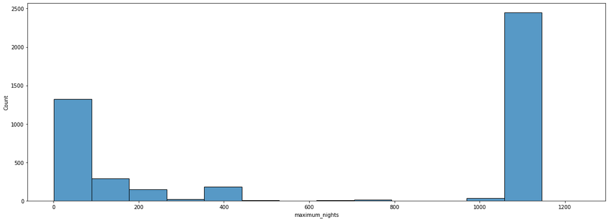

```python
fig, ax = plt.subplots(figsize=(20,7))
sns.histplot(data[data['maximum_nights']<2000]['maximum_nights'])
```

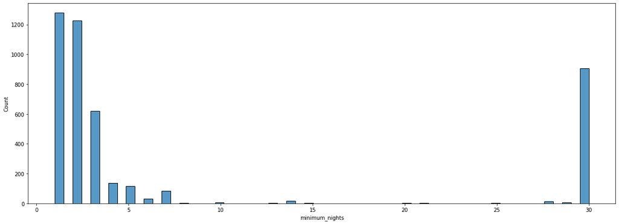

```python
fig, ax = plt.subplots(figsize=(20,7))
sns.histplot(data[data['minimum_nights']<=31]['minimum_nights'])
```

Podemos ver como la composicion de nuestros datos es bimodal en cuanto a la duracion de los contratos lo que nos obliga a realizar el proceso de prediccion dos veces: Un modelo para predecir los preciso de viviendas de corta duracion y otro para predecir los precios de viviendas de larga duracion.

### Distintas disponibilidades

Como tampoco sabiamos la descripcion ni la diferencia entre las distintas variables de disponibilidad hemos querido realizar un PCA y asi ver las correlacion y que explican cada una

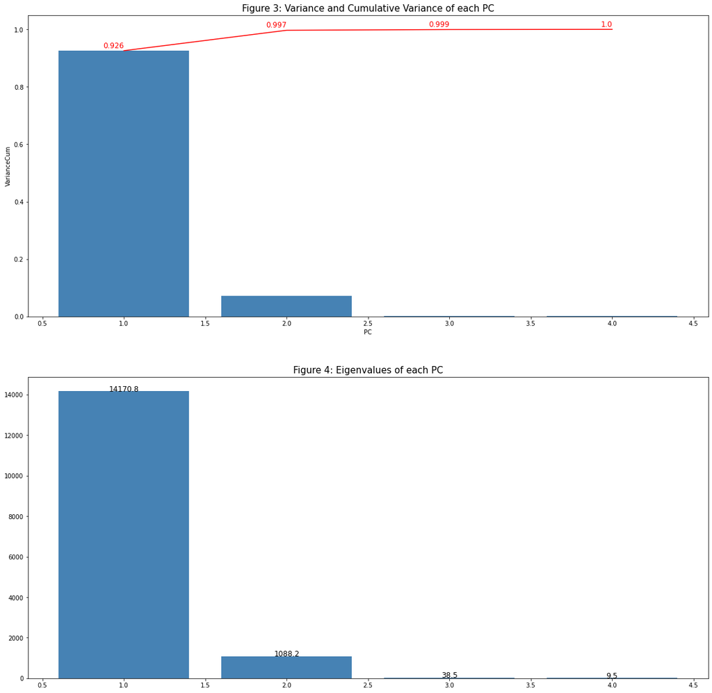

```python
data_pca_prueba = data[['availability_30', 'availability_60', 'availability_90', 'availability_365']]
data_pca_prueba.corr()

from sklearn.decomposition import PCA
PCA = PCA()
pca = PCA.fit(data_pca_prueba.dropna())
summary30_ = pd.DataFrame({'Variance' : pca.explained_variance_ratio_,
                          'VarianceCum' : pca.explained_variance_ratio_.cumsum(),
                          'Eigenvalue' : pca.explained_variance_,
                          'PC' : np.arange(1, len(pca.explained_variance_ratio_)+1)})

plt.figure(num = 3, figsize=(20,20))

plt.subplot(211)
plt.bar(data = summary30_,
         height = 'Variance', x = 'PC', color="steelblue")
sns.lineplot(data = summary30_,
         y = 'VarianceCum', x = 'PC', color="red")
for i, v in enumerate(round(summary30_.VarianceCum,3)):
    plt.text(summary30_.PC.tolist()[i], v+0.01, str(v), ha='right',
             fontsize=12, color = 'red')
plt.title('Figure 3: Variance and Cumulative Variance of each PC', size=15)

plt.subplot(212)
plt.figure(num = 3, figsize=(20,10))
plt.bar(data = summary30_,
         height = 'Eigenvalue', x = 'PC', color="steelblue")
for i, v in enumerate(round(summary30_.Eigenvalue,1)):
    plt.text(summary30_.PC.tolist()[i], v+2, str(v), ha='center',
             fontsize=12, color = 'black')
plt.title('Figure 4: Eigenvalues of each PC', size=15)
plt.show()
```

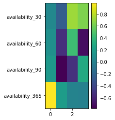

```python
data_availability= data.loc[:, ['availability_30', 'availability_60', 'availability_90', 'availability_365']]
fig, ax = plt.subplots(nrows=1, ncols=1, figsize=(2, 4))
componentes_ = pca.components_
plt.imshow(componentes_.T, cmap='viridis', aspect='auto')
plt.yticks(range(len(data_availability.columns)), data_availability.columns)
plt.xticks()
plt.grid(False)
plt.colorbar();
```

```python
pcs = pca.components_
normalized_pcs_ = list()

for eigen_vector in pcs:
    normalized_values = eigen_vector/eigen_vector.sum()
    normalized_pcs_.append(normalized_values)

pc_w = normalized_pcs_[0]
eigen_prtf1 = pd.DataFrame({'weights':pc_w.squeeze()} ,
                           index = data_availability.columns.values.tolist()[0:418])
eigen_prtf1
```

|  | weights |
| --- | --- |
| availability_30 | 0.034917 |
| availability_60 | 0.078770 |
| availability_90 | 0.126274 |
| availability_365 | 0.760039 |

Tras haber realizado el PCA hemos visto que la variable availability_365 explica el 76% de la componente principal, por lo que hemos decidido quedarnos con esta variable para explicar la disponibilidadde los alojamientos de canada, puesto a que las demas variables no aportan mucha informacion y podemos tener confusiones en su analisis.

Solo nos quedamos con availability_365 ya que explica mas del 70% de la componente pricipal

```python
data = data.drop(["availability_30", "availability_60", "availability_90"], axis = 1)
```

###### Transformaciones previas a division

Antes de realizar la division entre train y test, podemos realizar transformacion de un par de variables sin afectar a los datos:

- **property_type:** Hemos hallado las distintas categorias de la variable, y al ver que hay una mayoria que representa un porcentaje muy pequeño de los valores, hemos optado por sustituir los datos insignificantes por la categoria others y mantener los valores significativos con sus respectivas categorias
- **license:** Al tener un problema similar a la anterior variable, hemos decidido dividirlas en dos categorias, donde se dividen en los tipos de alojamiento exento de licencia y los tipos de alojamiento con licencia obligatoria
- **Eliminar variables:** Al no aportar mucha informacion necesaria para la estimacion de la variable objetivo (precio) hemos optado por eliminarlas ya que solo aportarian ruido a nuestro analisis (variables unicategoricas o bivariantes con distribuciones 99.99%/0.01%)

```python
distribucion_categorica(data['property_type']).index[distribucion_categorica(data['property_type'])['percent']<1]
data['property_type'] = ['Other' if a in distribucion_categorica(data['property_type']).index[distribucion_categorica(data['property_type'])['percent']<1] else a for a in data['property_type']]
```

```python
data['license'] = ['Exempt' if a == 'Exempt' else 'Mandatory' for a in data['license']]
```

```python
data = data.drop(['require_guest_profile_picture', 'require_guest_phone_verification', 'state', 'city', 'market', 'requires_license', 'street', 'neighbourhood_cleansed'], axis=1)
```

## TRAIN, TEST Y VALIDACION

Con la funcion *train_test_split()* hemos dividido el Data Set en train, test y validation, para poder entrenar el modelo y luego testar como de bien se estima con nuevas muestras. Por otra parte, generamos validation ya que una vez que hayamos probado nuestros modelos con test, aplicaremos estos sobre los datos de validacion para realizar una aproximacion lo mas fiel posible a un problema de negocio real.

```python
train, test_and_validation = train_test_split(data, test_size = 0.3, random_state = 123)
test, validation = train_test_split(test_and_validation, test_size = 1/3, random_state =123)
print("The train dataset has {} columns, the test dataset has {} columns and the validation dataset has {} columns".format(train.shape[0], test.shape[0], validation.shape[0]))
```

```
The train dataset has 3124 columns, the test dataset has 893 columns and the validation dataset has 447 columns
```

### Tratamiento valores missing

Con este codigo vamos a hallar los valores nulos totales por columna y su porcentaje total de estos, y asi saber si es necesario su tratamiento o directamente eliminamos la variable al contener un numeor elevado de valores missing

```python
pd_series_null_columns = train.isnull().sum().sort_values(ascending=False)
pd_null = pd.DataFrame(pd_series_null_columns, columns=['total_nulos'])
pd_null['porcentaje_NA'] = pd_null['total_nulos']/train.shape[0]
pd_null
```

|  | total_nulos | porcentaje_NA |
| --- | --- | --- |
| host_response_time | 1301 | 0.416453 |
| host_response_rate | 1301 | 0.416453 |
| security_deposit | 520 | 0.166453 |
| review_scores_location | 433 | 0.138604 |
| review_scores_communication | 433 | 0.138604 |
| review_scores_value | 433 | 0.138604 |
| review_scores_checkin | 433 | 0.138604 |
| review_scores_cleanliness | 432 | 0.138284 |
| review_scores_accuracy | 432 | 0.138284 |
| review_scores_rating | 432 | 0.138284 |
| reviews_per_month | 418 | 0.133803 |
| host_neighbourhood | 385 | 0.123239 |
| cleaning_fee | 268 | 0.085787 |
| neighbourhood | 180 | 0.057618 |
| beds | 3 | 0.000960 |
| host_identity_verified | 1 | 0.000320 |
| host_has_profile_pic | 1 | 0.000320 |
| host_total_listings_count | 1 | 0.000320 |
| host_listings_count | 1 | 0.000320 |
| bedrooms | 1 | 0.000320 |
| host_is_superhost | 1 | 0.000320 |
| last_review | 0 | 0.000000 |
| host_id | 0 | 0.000000 |
| cancellation_policy | 0 | 0.000000 |
| license | 0 | 0.000000 |
| instant_bookable | 0 | 0.000000 |
| number_of_reviews_ltm | 0 | 0.000000 |
| calculated_host_listings_count | 0 | 0.000000 |
| calculated_host_listings_count_entire_homes | 0 | 0.000000 |
| calculated_host_listings_count_private_rooms | 0 | 0.000000 |
| calculated_host_listings_count_shared_rooms | 0 | 0.000000 |
| first_review | 0 | 0.000000 |
| guests_included | 0 | 0.000000 |
| number_of_reviews | 0 | 0.000000 |
| bed_type | 0 | 0.000000 |
| latitude | 0 | 0.000000 |
| longitude | 0 | 0.000000 |
| is_location_exact | 0 | 0.000000 |
| property_type | 0 | 0.000000 |
| room_type | 0 | 0.000000 |
| accommodates | 0 | 0.000000 |
| bathrooms | 0 | 0.000000 |
| price | 0 | 0.000000 |
| availability_365 | 0 | 0.000000 |
| weekly_price | 0 | 0.000000 |
| monthly_price | 0 | 0.000000 |
| host_since | 0 | 0.000000 |
| extra_people | 0 | 0.000000 |
| minimum_nights | 0 | 0.000000 |
| maximum_nights | 0 | 0.000000 |
| calendar_updated | 0 | 0.000000 |
| maximum_factor | 0 | 0.000000 |

Primero vamos a almacenar dentro de list_var_cat todas las varibles categoricas y en list_var_continuous todas las variables numericas.

```python
list_var_cat, other = dame_variables_categoricas(dataset=train)
train[list_var_cat] = train[list_var_cat].astype("category", "object")
list_var_continuous = list(train.select_dtypes('float', "int64").columns)
train[list_var_continuous] = train[list_var_continuous].astype(float)
train.dtypes
```

```
host_id                                            int64
host_since                                       float64
host_response_time                              category
host_response_rate                              category
host_is_superhost                               category
host_neighbourhood                              category
host_listings_count                              float64
host_total_listings_count                        float64
host_has_profile_pic                            category
host_identity_verified                          category
neighbourhood                                   category
latitude                                         float64
longitude                                        float64
is_location_exact                               category
property_type                                   category
room_type                                       category
accommodates                                       int64
bathrooms                                        float64
bedrooms                                         float64
beds                                             float64
bed_type                                        category
price                                            float64
weekly_price                                     float64
monthly_price                                    float64
security_deposit                                 float64
cleaning_fee                                     float64
guests_included                                    int64
extra_people                                     float64
minimum_nights                                     int64
maximum_nights                                     int64
calendar_updated                                category
availability_365                                   int64
number_of_reviews                                  int64
number_of_reviews_ltm                              int64
first_review                                     float64
last_review                                      float64
review_scores_rating                             float64
review_scores_accuracy                           float64
review_scores_cleanliness                        float64
review_scores_checkin                            float64
review_scores_communication                      float64
review_scores_location                           float64
review_scores_value                              float64
license                                         category
instant_bookable                                category
cancellation_policy                             category
calculated_host_listings_count                     int64
calculated_host_listings_count_entire_homes        int64
calculated_host_listings_count_private_rooms       int64
calculated_host_listings_count_shared_rooms        int64
reviews_per_month                                float64
maximum_factor                                   float64
dtype: object
```

Pata el tratamiento de datos missing en variables numericas, hemos optado por sustituir los valores de los tres data sets por la media de esa columan del data set train

```python
for i in list_var_continuous:
    train[i] = train[i].fillna(train[i].mean())
    test[i] = test[i].fillna(train[i].mean())
    validation[i] = validation[i].fillna(train[i].mean())
```

#### Transformación de variables categoricas a variables numéricas, para su tratamiento de datos missing

Primero hemos tranformado las variables categoricas a numericas para simplifiacar su tratamiento. con un *LablEncoder()*

```python
le = LabelEncoder()
train['host_since'] = le.fit_transform(train['host_since'])
train['host_response_time'] = le.fit_transform(train['host_response_time'])
train['host_response_rate'] = le.fit_transform(train['host_response_rate'])
train['host_is_superhost'] = le.fit_transform(train['host_is_superhost'])

test['host_since'] = le.fit_transform(test['host_since'])
test['host_response_time'] = le.fit_transform(test['host_response_time'])
test['host_response_rate'] = le.fit_transform(test['host_response_rate'])
test['host_is_superhost'] = le.fit_transform(test['host_is_superhost'])

validation['host_since'] = le.fit_transform(validation['host_since'])
validation['host_response_time'] = le.fit_transform(validation['host_response_time'])
validation['host_response_rate'] = le.fit_transform(validation['host_response_rate'])
validation['host_is_superhost'] = le.fit_transform(validation['host_is_superhost'])


train.head()
```

| id | host_id | host_since | host_response_time | host_response_rate | host_is_superhost | host_neighbourhood | host_listings_count | host_total_listings_count | host_has_profile_pic | host_identity_verified | neighbourhood | latitude | longitude | is_location_exact | property_type | room_type | accommodates | bathrooms | bedrooms | beds | bed_type | price | weekly_price | monthly_price | security_deposit | cleaning_fee | guests_included | extra_people | minimum_nights | … |
| --- | --- | --- | --- | --- | --- | --- | --- | --- | --- | --- | --- | --- | --- | --- | --- | --- | --- | --- | --- | --- | --- | --- | --- | --- | --- | --- | --- | --- | --- | --- |
| 31176668 | 231211816 | 116 | 3 | 34 | 0 | Yaletown | 3.0 | 3.0 | t | f | West End | 49.286589 | -123.124494 | t | Condominium | Entire home/apt | 8 | 2.0 | 2.0 | 3.0 | Real Bed | 600.0 | 2688.00 | 8784.00 | 300.0 | 99.0 | 4 | 45.0 | 2 | … |
| 31464757 | 235711413 | 117 | 4 | 35 | 0 | NaN | 1.0 | 1.0 | t | f | Downtown Vancouver | 49.280543 | -123.124506 | f | Apartment | Entire home/apt | 3 | 1.0 | 1.0 | 1.0 | Real Bed | 350.0 | 1568.00 | 5124.00 | 0.0 | 55.0 | 2 | 35.0 | 2 | … |
| 22298691 | 139891966 | 99 | 4 | 35 | 0 | Fairview | 27.0 | 27.0 | t | f | Fairview | 49.260064 | -123.126085 | t | Condominium | Entire home/apt | 4 | 2.0 | 2.0 | 2.0 | Real Bed | 100.0 | 448.00 | 1464.00 | 1500.0 | 60.0 | 1 | 0.0 | 30 | … |
| 28560492 | 46440927 | 78 | 3 | 1 | 0 | NaN | 1.0 | 1.0 | t | t | Killarney | 49.205810 | -123.031507 | f | Condominium | Entire home/apt | 2 | 1.0 | 1.0 | 1.0 | Real Bed | 94.0 | 421.12 | 1376.16 | 200.0 | 50.0 | 2 | 50.0 | 2 | … |
| 19866598 | 113812826 | 93 | 3 | 1 | 1 | Renfrew-Collingwood | 6.0 | 6.0 | t | f | Renfrew-Collingwood | 49.240497 | -123.040059 | t | House | Entire home/apt | 8 | 2.0 | 3.0 | 4.0 | Real Bed | 420.0 | 1881.60 | 6148.80 | 250.0 | 150.0 | 6 | 20.0 | 2 | … |

A continuación, realizamos el encoding de las variables caategóricas restantes de distintas maneras:

```python
list_other = ['host_has_profile_pic' ,'host_identity_verified' ,'property_type', 'license', 'instant_bookable', "is_location_exact"]
ohe = ce.OneHotEncoder(cols=list_other)
train = ohe.fit_transform(train)
test = ohe.fit_transform(test)
validation = ohe.fit_transform(validation)
```

```python
encoder = ce.TargetEncoder()

train['calendar_updated'] = encoder.fit_transform(train.calendar_updated, train.price.values).values
test['calendar_updated'] = encoder.transform(test.calendar_updated, test.price).values
validation['calendar_updated'] = encoder.transform(validation.calendar_updated, validation.price).values

train['room_type'] = encoder.fit_transform(train.room_type, train.price.values).values
test['room_type'] = encoder.transform(test.room_type, test.price).values
validation['room_type'] = encoder.transform(validation.room_type, validation.price).values

train['bed_type'] = encoder.fit_transform(train.bed_type, train.price.values).values
test['bed_type'] = encoder.transform(test.bed_type, test.price).values
validation['bed_type'] = encoder.transform(validation.bed_type, validation.price).values

train['cancellation_policy'] = encoder.fit_transform(train.cancellation_policy, train.price.values).values
test['cancellation_policy'] = encoder.transform(test.cancellation_policy, test.price).values
validation['cancellation_policy'] = encoder.transform(validation.cancellation_policy, validation.price).values
```

```python
train_knn = train[['host_neighbourhood', 'neighbourhood', 'bedrooms' , 'accommodates','price']]
label = LabelEncoder()
train_knn = train_knn.apply(lambda series: pd.Series(label.fit_transform(series[series.notnull()]), index=series[series.notnull()].index))
imputer = KNNImputer(n_neighbors=1)
train_knn = pd.DataFrame(imputer.fit_transform(train_knn), columns = ['host_neighbourhood', 'neighbourhood', 'bedrooms' , 'accommodates','price'])
train['host_neighbourhood'] = train_knn['host_neighbourhood'].values
train['neighbourhood'] = train_knn['neighbourhood'].values

test_knn = test[['host_neighbourhood', 'neighbourhood', 'bedrooms' , 'accommodates','price']]
label = LabelEncoder()
test_knn = test_knn.apply(lambda series: pd.Series(label.fit_transform(series[series.notnull()]), index=series[series.notnull()].index))
imputer = KNNImputer(n_neighbors=1)
test_knn = pd.DataFrame(imputer.fit_transform(test_knn), columns = ['host_neighbourhood', 'neighbourhood', 'bedrooms' , 'accommodates','price'])
test['host_neighbourhood'] = test_knn['host_neighbourhood'].values
test['neighbourhood'] = test_knn['neighbourhood'].values

validation_knn = validation[['host_neighbourhood', 'neighbourhood', 'bedrooms' , 'accommodates','price']]
label = LabelEncoder()
validation_knn = validation_knn.apply(lambda series: pd.Series(label.fit_transform(series[series.notnull()]), index=series[series.notnull()].index))
imputer = KNNImputer(n_neighbors=1)
validation_knn = pd.DataFrame(imputer.fit_transform(validation_knn), columns = ['host_neighbourhood', 'neighbourhood', 'bedrooms' , 'accommodates','price'])
validation['host_neighbourhood'] = validation_knn['host_neighbourhood'].values
validation['neighbourhood'] = validation_knn['neighbourhood'].values
```

### Comprobación de los datos missing

Hemos vuelto a realizar la tabla de valores missing de cada columna, pero esta vez hemos añadido las columnas para test y validation. Estas ultimas se han añadido ya que no queremos que haya ningun valor missing en ninguna muestra

```python
pd_series_null_columns1 = train.isnull().sum().sort_values(ascending=False)
pd_series_null_columns2 = test.isnull().sum().sort_values(ascending=False)
pd_series_null_columns3 = validation.isnull().sum().sort_values(ascending=False)

pd_null1 = pd.DataFrame(pd_series_null_columns1, columns=['total_nulos_train'])
pd_null1['porcentaje_NA_train'] = pd_null1['total_nulos_train']/train.shape[0]
pd_null1['total_nulos_test'] = pd_series_null_columns2
pd_null1['porcentaje_NA_test'] =pd_null1['total_nulos_test']/test.shape[0]
pd_null1['total_nulos_validation'] = pd_series_null_columns3
pd_null1['porcentaje_NA_validation'] =pd_null1['total_nulos_validation']/validation.shape[0]
pd_null1
```

|  | total_nulos_train | porcentaje_NA_train | total_nulos_test | porcentaje_NA_test | total_nulos_validation | porcentaje_NA_validation |
| --- | --- | --- | --- | --- | --- | --- |
| host_id | 0 | 0.0 | 0.0 | 0.0 | 0.0 | 0.0 |
| maximum_nights | 0 | 0.0 | 0.0 | 0.0 | 0.0 | 0.0 |
| last_review | 0 | 0.0 | 0.0 | 0.0 | 0.0 | 0.0 |
| first_review | 0 | 0.0 | 0.0 | 0.0 | 0.0 | 0.0 |
| number_of_reviews_ltm | 0 | 0.0 | 0.0 | 0.0 | 0.0 | 0.0 |
| ... | ... | ... | ... | ... | ... | ... |
| property_type_10 | 0 | 0.0 | 0.0 | 0.0 | 0.0 | 0.0 |
| room_type | 0 | 0.0 | 0.0 | 0.0 | 0.0 | 0.0 |
| accommodates | 0 | 0.0 | 0.0 | 0.0 | 0.0 | 0.0 |
| bathrooms | 0 | 0.0 | 0.0 | 0.0 | 0.0 | 0.0 |
| maximum_factor | 0 | 0.0 | 0.0 | 0.0 | 0.0 | 0.0 |

68 rows × 6 columns

### Tratamiento de train, test y validation

Vamos a dividir train segun la duracion de la estancia (corta duracion y larga duracion) para poder realizar todos los modelos sobre estas dos muestras. Para establecer un punto de corte, tenemos en cuenta el valor 0 en la Componente Principal que representa esta carácteristica y que hemos creado previamente.

Ya que ne ocasiones los encoder que hemos utilizado previamente hacen que haya columnas en train que no estémn en test y viceversa, hemos seleccionado tansolo las columnas comunes en ambos df para evitar problemas a la hora de entrenar y predecir los siguientes modelos.

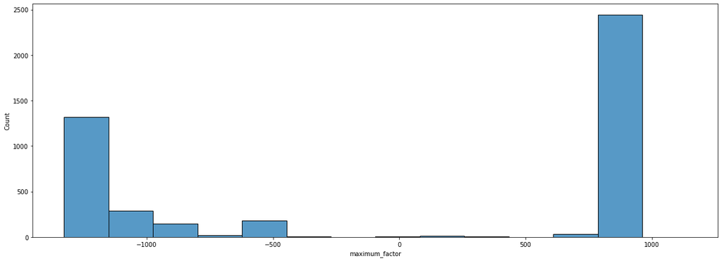

```python
fig, ax = plt.subplots(figsize=(20,7))
sns.histplot(data[data['maximum_factor']<2000]["maximum_factor"])
```

```python
train_ld =  train[train['maximum_factor'] >= 0]
train_cd = train[train['maximum_factor'] < 0]
test_ld =  test[test['maximum_factor'] >= 0]
test_cd = test[test['maximum_factor'] < 0]
validation_ld =  validation[validation['maximum_factor'] >= 0]
validation_cd = validation[validation['maximum_factor'] < 0]

train_ld = train_ld[np.intersect1d(np.intersect1d(train_ld.columns, test_ld.columns), validation_ld.columns)]
test_ld = test_ld[np.intersect1d(np.intersect1d(train_ld.columns, test_ld.columns), validation_ld.columns)]
validation_ld = validation_ld[np.intersect1d(np.intersect1d(train_ld.columns, test_ld.columns), validation_ld.columns)]

train_cd = train_cd[np.intersect1d(np.intersect1d(train_cd.columns, test_cd.columns), validation_cd.columns)]
test_cd = test_cd[np.intersect1d(np.intersect1d(train_cd.columns, test_cd.columns), validation_cd.columns)]
validation_cd = validation_cd[np.intersect1d(np.intersect1d(train_cd.columns, test_cd.columns), validation_cd.columns)]
```

#### División por la variable objetivo precio

Separamos la variable objetivo del resto de datos

```python
X_train_cd = train_cd.drop(["price"], axis = 1)
X_test_cd = test_cd.drop(["price"], axis = 1)
X_validation_cd = validation_cd.drop(["price"], axis = 1)
```

```python
X_train_ld = train_ld.drop(["price"], axis = 1)
X_test_ld = test_ld.drop(["price"], axis = 1)
X_validation_ld = validation_ld.drop(["price"], axis = 1)
```

```python
y_train_cd = train_cd["price"]
y_test_cd = test_cd["price"]
y_validation_cd = validation_cd["price"]
```

```python
y_train_ld = train_ld["price"]
y_test_ld = test_ld["price"]
y_validation_ld = validation_ld["price"]
```

### Correlaciones

Por último, realizamos un pequeño análisis de correlaciones para eliminar aquellas variables que repitan informacion.

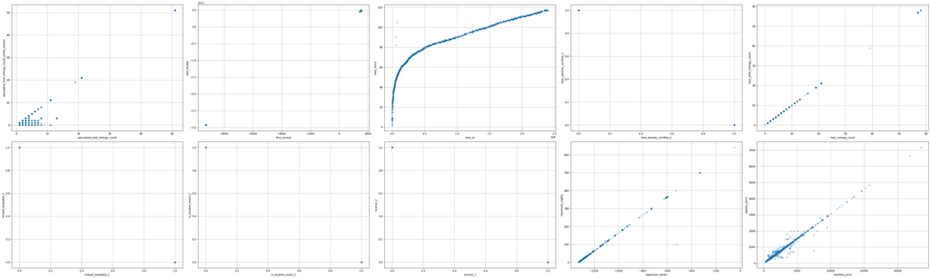

```python
from matplotlib.colors import ListedColormap
cm = plt.cm.RdBu
cm_bright = ListedColormap(['#FF0000', '#0000FF'])

corr_matrix = X_train_cd.corr().abs()

upper = corr_matrix.where(np.triu(np.ones(corr_matrix.shape), k=1).astype(np.bool))

pairs = np.where(upper>0.90)
fx = X_train_cd.columns[pairs[0]]
fy = X_train_cd.columns[pairs[1]]

i=1
plt.figure(figsize=(50,22))
for f1,f2 in zip(fx,fy):

    plt.subplot(3,5,i)

    plt.scatter(X_train_cd[f1],X_train_cd[f2],cmap=cm_bright, alpha=0.25)
    plt.xlabel(f1)
    plt.ylabel(f2)
    plt.grid()
    plt.tight_layout()

    i+=1

plt.show()
```

```python
X_train_cd = X_train_cd.drop(["monthly_price", "host_id"], axis = 1)
X_test_cd = X_test_cd.drop(["monthly_price", "host_id"], axis = 1)
X_validation_cd = X_validation_cd.drop(["monthly_price", "host_id"], axis = 1)
```

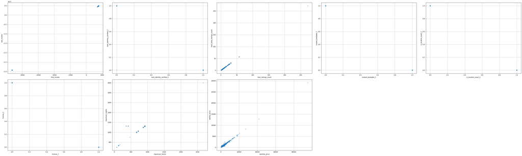

```python
from matplotlib.colors import ListedColormap
cm = plt.cm.RdBu
cm_bright = ListedColormap(['#FF0000', '#0000FF'])

corr_matrix = X_train_ld.corr().abs()

upper = corr_matrix.where(np.triu(np.ones(corr_matrix.shape), k=1).astype(np.bool))

pairs = np.where(upper>0.90)
fx = X_train_ld.columns[pairs[0]]
fy = X_train_ld.columns[pairs[1]]

i=1
plt.figure(figsize=(50,22))
for f1,f2 in zip(fx,fy):

    plt.subplot(3,5,i)

    plt.scatter(X_train_ld[f1],X_train_ld[f2],cmap=cm_bright, alpha=0.25)
    plt.xlabel(f1)
    plt.ylabel(f2)
    plt.grid()
    plt.tight_layout()

    i+=1

plt.show()
```

```python
X_train_ld = X_train_ld.drop(["weekly_price", "host_id"], axis = 1)
X_test_ld = X_test_ld.drop(["weekly_price", "host_id"], axis = 1)
X_validation_ld = X_validation_ld.drop(["weekly_price", "host_id"], axis = 1)
```

## **Predicciones**

Primero de todo, vamos a generar una **tabla para almacenar los resultados de los modelos** y poder compararlos de manera más sencilla.

```python
tabla_resultados= pd.DataFrame(columns=['Modelo', 'RMSE', 'R2'])
```

Al tratarse de un problema de regresión, dado que la variable objetivo predice valores continuos, los modelos más convenientes que se van a llevar a cabo son:

- **Random Forest:** Se ha realizado un **Random Forest inicial** teniendo en cuenta todas las variables ya tratadas previamente, y un **Random Forest final** donde se han seleccionado las variables más relevantes para el empleo del modelo.
- **Regresión Logística**
- **XG Boost**
- **Support Vector Machine**
- **Redes neuronales**

Todos ellos se van a realizar tanto para las estancias de corta duración como las de larga duración.

### Random Forest inicial CD

Hemos probado cual es el óptimo de árboles que tiene el Random Forest en el rango de 75 y 1500 y hemos comprobado que el número óptimo para este modelo es de 200 con un cross validation.

Asimismo, hemos probado los árboles en su profundidad en un rango de 2 a 100 alturas, siendo el óptimo de 6.

Por tanto, hemos seleccionado un max_depth de 6 y un n_estimators de 200.

```python
param_grid_cd = {'n_estimators': [200],
              'max_depth'   : [6]}

grid_cd = GridSearchCV(
        estimator  = RandomForestRegressor(random_state = 123),
        param_grid = param_grid_cd,
        n_jobs     = multiprocessing.cpu_count() - 1,
        cv         = RepeatedKFold(n_splits=5, n_repeats=3, random_state=123),
        refit      = True,
        verbose    = 0,
        return_train_score = True
       )

grid_cd.fit(X = X_train_cd.values.astype(float), y = y_train_cd.values.astype(float))

resultados = pd.DataFrame(grid_cd.cv_results_)
resultados.filter(regex = '(param*|mean_t|std_t)') \
    .drop(columns = 'params') \
    .sort_values('mean_test_score', ascending = False) \
    .head(4)
```

|  | param_max_depth | param_n_estimators | mean_test_score | std_test_score | mean_train_score | std_train_score |
| --- | --- | --- | --- | --- | --- | --- |
| 0 | 6 | 200 | 0.954283 | 0.022997 | 0.986547 | 0.001259 |

Se va a calcular el error cuadrático medio y el R-cuadrado que presenta el Random Forest inicial para los apartamentos de corta duración:

- **Error cuadrático medio:** Mide el error cuadrado promedio de nuestras predicciones. Para cada punto, calcula la diferencia cuadrada entre las predicciones y el objetivo y luego promedia esos valores. La raíz cuadrática del error cuadrático medio de este modelo es de 21,99 unidades monetarias, por lo que es un error bajo y por tanto, puede ser un buen modelo.
- **R-cuadrado:** Indica la aptitud del modelo. Muestra que también las variables independientes seleccionadas explican la variabilidad en sus variables dependiente. El modelo explica un 97,39% de lo que se quiere explicar.

Debido a su bajo error cuadrático medio y a su alto R-cuadrado se considera un buen modelo.

```python
modelo_final_cd = grid_cd.best_estimator_
predicciones_cd = modelo_final_cd.predict(X = X_test_cd)

mse_rf_cd= mean_squared_error(predicciones_cd, y_test_cd, squared=False)
r2_rf_cd = r2_score(y_test_cd.values.ravel(), predicciones_cd)

tabla_resultados = tabla_resultados.append({'Modelo': 'Random Forest corta duración inicial', 'RMSE': mse_rf_cd, 'R2': r2_rf_cd}, ignore_index=True)

print('Mean Squared Error:', round(mse_rf_cd, 4))
print('R-squared scores:', round(r2_rf_cd, 4))
```

```
Mean Squared Error: 21.9939
R-squared scores: 0.9739
```

```
Feature: 0, Score: 0.00077
Feature: 1, Score: 0.00404
Feature: 2, Score: 0.00113
Feature: 3, Score: 0.00000
Feature: 4, Score: 0.00057
Feature: 5, Score: 0.00102
Feature: 6, Score: 0.00012
Feature: 7, Score: 0.00017
Feature: 8, Score: 0.00003
Feature: 9, Score: 0.00000
Feature: 10, Score: 0.00016
Feature: 11, Score: 0.00027
Feature: 12, Score: 0.00062
Feature: 13, Score: 0.00023
Feature: 14, Score: 0.00060
Feature: 15, Score: 0.00053
Feature: 16, Score: 0.00000
Feature: 17, Score: 0.00003
Feature: 18, Score: 0.00002
Feature: 19, Score: 0.00004
Feature: 20, Score: 0.00013
Feature: 21, Score: 0.00021
Feature: 22, Score: 0.00005
Feature: 23, Score: 0.00017
Feature: 24, Score: 0.00198
Feature: 25, Score: 0.00009
Feature: 26, Score: 0.00002
Feature: 27, Score: 0.00002
Feature: 28, Score: 0.00002
Feature: 29, Score: 0.00001
Feature: 30, Score: 0.00076
Feature: 31, Score: 0.00201
Feature: 32, Score: 0.00001
Feature: 33, Score: 0.00000
Feature: 34, Score: 0.00067
Feature: 35, Score: 0.00286
Feature: 36, Score: 0.00041
Feature: 37, Score: 0.00146
Feature: 38, Score: 0.00031
Feature: 39, Score: 0.00069
Feature: 40, Score: 0.00025
Feature: 41, Score: 0.00002
Feature: 42, Score: 0.00000
Feature: 43, Score: 0.00002
Feature: 44, Score: 0.00007
Feature: 45, Score: 0.00001
Feature: 46, Score: 0.00001
Feature: 47, Score: 0.00152
Feature: 48, Score: 0.00005
Feature: 49, Score: 0.00000
Feature: 50, Score: 0.00000
Feature: 51, Score: 0.00005
Feature: 52, Score: 0.00006
Feature: 53, Score: 0.00006
Feature: 54, Score: 0.00003
Feature: 55, Score: 0.00001
Feature: 56, Score: 0.00020
Feature: 57, Score: 0.00010
Feature: 58, Score: 0.00128
Feature: 59, Score: 0.00004
Feature: 60, Score: 0.00024
Feature: 61, Score: 0.97374
```

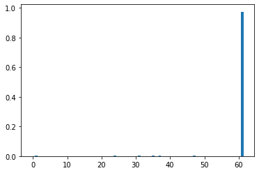

```python
importance_cd = modelo_final_cd.feature_importances_
for i,v in enumerate(importance_cd):
    print('Feature: %0d, Score: %.5f' % (i,v))
pyplot.bar([x for x in range(len(importance_cd))], importance_cd)
pyplot.show()
```

```python
import_vars_cd=[]
for i in range(len(X_train_cd.columns)):
    col = X_train_cd.columns[i]
    val = importance_cd[i]
    if val > 0.001:
        import_vars_cd.append(col)
import_vars_cd
```

```
['availability_365',
 'bathrooms',
 'beds',
 'host_since',
 'latitude',
 'maximum_factor',
 'minimum_nights',
 'property_type_6',
 'reviews_per_month',
 'weekly_price']
```

```python
del grid_cd
del modelo_final_cd
```

### Random Forest inicial LD

Hemos probado cual es el óptimo de árboles que tiene el Random Forest en el rango de 70 y 1000 y hemos comprobado que el número óptimo para este modelo es de 70 con un cross validation.

Asimismo, hemos probado los árboles en su profundidad en un rango de 2 a 40 alturas, siendo el óptimo de 8.

Por tanto, hemos seleccionado un max_depth de 8 y un n_estimators de 70.

```python
param_grid_ld = {'n_estimators': [70],
              'max_depth'   : [8]}

grid_ld = GridSearchCV(
        estimator  = RandomForestRegressor(random_state = 123),
        param_grid = param_grid_ld,
        n_jobs     = multiprocessing.cpu_count() - 1,
        cv         = RepeatedKFold(n_splits=5, n_repeats=3, random_state=123),
        refit      = True,
        verbose    = 0,
        return_train_score = True
       )

grid_ld.fit(X = X_train_ld.values, y = y_train_ld.values)

resultados = pd.DataFrame(grid_ld.cv_results_)
resultados.filter(regex = '(param*|mean_t|std_t)') \
    .drop(columns = 'params') \
    .sort_values('mean_test_score', ascending = False) \
    .head(4)
```

|  | param_max_depth | param_n_estimators | mean_test_score | std_test_score | mean_train_score | std_train_score |
| --- | --- | --- | --- | --- | --- | --- |
| 0 | 8 | 70 | 0.84504 | 0.176793 | 0.958089 | 0.017776 |

Se va a calcular el error cuadrático medio y el R cuadrado que presenta el Random Forest inicial para los apartamentos de larga duración:

- **Error cuadrático medio:** Mide el error cuadrado promedio de nuestras predicciones. Para cada punto, calcula la diferencia cuadrada entre las predicciones y el objetivo y luego promedia esos valores. La raíz cuadrática del error cuadrático medio de este modelo es de 20,75 unidades monetarias, por lo que es un error bajo y por tanto, un buen modelo.
- **R-cuadrado:** Indica la aptitud del modelo. Muestra que también las variables independientes seleccionadas explican la variabilidad en sus variables dependiente. El modelo explica un 98,66% de lo que se quiere explicar.

Debido a su bajo error cuadrático medio y a su alto R-cuadrado se considera un buen modelo.

```python
modelo_final_ld = grid_ld.best_estimator_
predicciones_ld = modelo_final_ld.predict(X = X_test_ld)

mse_rf_ld = mean_squared_error(predicciones_ld, y_test_ld, squared=False)
r2_rf_ld = r2_score(y_test_ld.values.ravel(), predicciones_ld)

tabla_resultados = tabla_resultados .append({'Modelo': 'Random Forest larga duración inicial', 'RMSE': mse_rf_ld, 'R2': r2_rf_ld}, ignore_index=True)

print('Mean Squared Error:', round(mse_rf_ld, 4))
print('R-squared scores:', round(r2_rf_ld, 4))
```

```
Mean Squared Error: 20.7539
R-squared scores: 0.9866
```

```
Feature: 0, Score: 0.00200
Feature: 1, Score: 0.00519
Feature: 2, Score: 0.00050
Feature: 3, Score: 0.00000
Feature: 4, Score: 0.00104
Feature: 5, Score: 0.00525
Feature: 6, Score: 0.00595
Feature: 7, Score: 0.00038
Feature: 8, Score: 0.00007
Feature: 9, Score: 0.00000
Feature: 10, Score: 0.00281
Feature: 11, Score: 0.00214
Feature: 12, Score: 0.00482
Feature: 13, Score: 0.00076
Feature: 14, Score: 0.00202
Feature: 15, Score: 0.00027
Feature: 16, Score: 0.00000
Feature: 17, Score: 0.00004
Feature: 18, Score: 0.00002
Feature: 19, Score: 0.00001
Feature: 20, Score: 0.00266
Feature: 21, Score: 0.00028
Feature: 22, Score: 0.00005
Feature: 23, Score: 0.00038
Feature: 24, Score: 0.00133
Feature: 25, Score: 0.00280
Feature: 26, Score: 0.00001
Feature: 27, Score: 0.00023
Feature: 28, Score: 0.00001
Feature: 29, Score: 0.00000
Feature: 30, Score: 0.00394
Feature: 31, Score: 0.00058
Feature: 32, Score: 0.00049
Feature: 33, Score: 0.00029
Feature: 34, Score: 0.00076
Feature: 35, Score: 0.00056
Feature: 36, Score: 0.00002
Feature: 37, Score: 0.00115
Feature: 38, Score: 0.93108
Feature: 39, Score: 0.00048
Feature: 40, Score: 0.00070
Feature: 41, Score: 0.00150
Feature: 42, Score: 0.00005
Feature: 43, Score: 0.00000
Feature: 44, Score: 0.00009
Feature: 45, Score: 0.00004
Feature: 46, Score: 0.00000
Feature: 47, Score: 0.00001
Feature: 48, Score: 0.00001
Feature: 49, Score: 0.00001
Feature: 50, Score: 0.00000
Feature: 51, Score: 0.00002
Feature: 52, Score: 0.00128
Feature: 53, Score: 0.00587
Feature: 54, Score: 0.00145
Feature: 55, Score: 0.00121
Feature: 56, Score: 0.00004
Feature: 57, Score: 0.00244
Feature: 58, Score: 0.00009
Feature: 59, Score: 0.00437
Feature: 60, Score: 0.00000
Feature: 61, Score: 0.00044
```

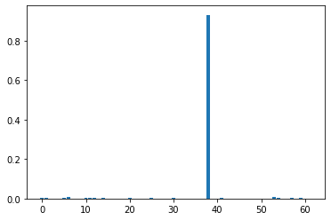

```python
importance_ld = modelo_final_ld.feature_importances_

for i,v in enumerate(importance_ld):
    print('Feature: %0d, Score: %.5f' % (i,v))

pyplot.bar([x for x in range(len(importance_ld))], importance_ld)
pyplot.show()
```

```python
import_vars_ld=[]
for i in range(len(X_train_ld.columns)):
    col = X_train_ld.columns[i]
    val = importance_ld[i]
    if val > 0.005:
        import_vars_ld.append(col)
import_vars_ld
```

```
['availability_365',
 'beds',
 'calculated_host_listings_count',
 'monthly_price',
 'review_scores_checkin']
```

```python
del grid_ld
del modelo_final_ld
```

### Random Forest final CD

Hemos probado cual es el óptimo de árboles que tiene el Random Forest final en el rango de 75 y 1000 y hemos comprobado que el número óptimo para este modelo es de 250 con un cross validation.

Asimismo, hemos probado los árboles en su profundidad en un rango de 2 a 40 alturas, siendo el óptimo de 8.

Por tanto, hemos seleccionado un max_depth de 8 y un n_estimators de 250.

```python
X_train_cd_1 = X_train_cd[X_train_cd.columns.intersection(import_vars_cd)]
X_test_cd_1 = X_test_cd[X_test_cd.columns.intersection(import_vars_cd)]
X_validation_cd_1 = X_validation_cd[X_validation_cd.columns.intersection(import_vars_cd)]
```

```python
param_grid_cd_1 = {'n_estimators': [250],
              'max_depth'   : [8]}

grid_cd_1 = GridSearchCV(
        estimator  = RandomForestRegressor(random_state = 123),
        param_grid = param_grid_cd_1,
        n_jobs     = multiprocessing.cpu_count() - 1,
        cv         = RepeatedKFold(n_splits=5, n_repeats=3, random_state=123),
        refit      = True,
        verbose    = 0,
        return_train_score = True
       )

grid_cd_1.fit(X = X_train_cd_1, y = y_train_cd)

resultados = pd.DataFrame(grid_cd_1.cv_results_)
resultados.filter(regex = '(param*|mean_t|std_t)') \
    .drop(columns = 'params') \
    .sort_values('mean_test_score', ascending = False) \
    .head(4)
```

|  | param_max_depth | param_n_estimators | mean_test_score | std_test_score | mean_train_score | std_train_score |
| --- | --- | --- | --- | --- | --- | --- |
| 0 | 8 | 250 | 0.959579 | 0.019691 | 0.992211 | 0.000876 |

Se va a calcular el error cuadrático medio y el R cuadrado que presenta el Random Forest final, -con las variables más relevantes seleccionadas- para los apartamentos de corta duración:

- **Error cuadrático medio:** Mide el error cuadrado promedio de nuestras predicciones. Para cada punto, calcula la diferencia cuadrada entre las predicciones y el objetivo y luego promedia esos valores. La raíz cuadrática del error cuadrático medio es de 21,26 unidades monetarias, por lo que es un error bajo y por tanto, un buen modelo.
- **R-cuadrado:** Indica la aptitud del modelo. Muestra que también las variables independientes seleccionadas explican la variabilidad en sus variables dependiente. El modelo explica un 97,57% de lo que se quiere explicar.

Debido a su bajo error cuadrático medio y a su alto R-cuadrado se considera un buen modelo.

```python
modelo_final_cd_1 = grid_cd_1.best_estimator_
predicciones_cd_1 = modelo_final_cd_1.predict(X = X_test_cd_1)

mse_rf_cd_1 = mean_squared_error(predicciones_cd_1, y_test_cd, squared=False)
r2_rf_cd_1 = r2_score(y_test_cd.values.ravel(), predicciones_cd_1)

tabla_resultados = tabla_resultados.append({'Modelo': 'Random Forest corta duración final', 'RMSE': mse_rf_cd_1 , 'R2': r2_rf_cd_1}, ignore_index=True)

print('Mean Squared Error:', round(mse_rf_cd_1, 4))
print('R-squared scores:', round(r2_rf_cd_1, 4))
```

```
Mean Squared Error: 21.26
R-squared scores: 0.9756
```

### Random Forest final LD

Hemos probado cual es el óptimo de árboles que tiene el Random Forest final en el rango de 75 y 1000 y hemos comprobado que el número óptimo para este modelo es de 80 con un cross validation.

Asimismo, hemos probado los árboles en su profundidad en un rango de 2 a 40 alturas, siendo el óptimo de 6.

Por tanto, hemos seleccionado un max_depth de 6 y un n_estimators de 80.

```python
X_train_ld_1 = X_train_ld[X_train_ld.columns.intersection(import_vars_ld)]
X_test_ld_1 = X_test_ld[X_test_ld.columns.intersection(import_vars_ld)]
X_validation_ld_1 = X_validation_ld[X_validation_ld.columns.intersection(import_vars_ld)]
```

```python
param_grid_ld_1 = {'n_estimators': [80],
              'max_depth'   : [6]}

grid_ld_1 = GridSearchCV(
        estimator  = RandomForestRegressor(random_state = 123),
        param_grid = param_grid_ld_1,
        n_jobs     = multiprocessing.cpu_count() - 1,
        cv         = RepeatedKFold(n_splits=5, n_repeats=3, random_state=123),
        refit      = True,
        verbose    = 0,
        return_train_score = True
       )

grid_ld_1.fit(X = X_train_ld_1, y = y_train_ld)

resultados = pd.DataFrame(grid_ld_1.cv_results_)
resultados.filter(regex = '(param*|mean_t|std_t)') \
    .drop(columns = 'params') \
    .sort_values('mean_test_score', ascending = False) \
    .head(4)
```

|  | param_max_depth | param_n_estimators | mean_test_score | std_test_score | mean_train_score | std_train_score |
| --- | --- | --- | --- | --- | --- | --- |
| 0 | 6 | 80 | 0.863525 | 0.164408 | 0.960188 | 0.014277 |

Se va a calcular el error cuadrático medio y el R cuadrado que presenta el Random Forest final, -con las variables más relevantes seleccionadas- para los apartamentos de larga duración:

- **Error cuadrático medio:** Mide el error cuadrado promedio de nuestras predicciones. Para cada punto, calcula la diferencia cuadrada entre las predicciones y el objetivo y luego promedia esos valores. La raíz cuadrática del error cuadrático medio de este modelo es de 20,97 unidades monetarias, por lo que es un error bajo y por tanto, un buen modelo.
- **R-cuadrado:** Indica la aptitud del modelo. Muestra que también las variables independientes seleccionadas explican la variabilidad en sus variables dependiente. El modelo explica un 98,63% de lo que se quiere explicar.

Debido a su bajo error cuadrático medio y a su alto R-cuadrado se considera un buen modelo.

```python
modelo_final_ld_1 = grid_ld_1.best_estimator_
predicciones_ld_1 = modelo_final_ld_1.predict(X = X_test_ld_1)

mse_rf_ld_1 = mean_squared_error(predicciones_ld_1, y_test_ld, squared=False)
r2_rf_ld_1 = r2_score(y_test_ld.values.ravel(), predicciones_ld_1)

tabla_resultados = tabla_resultados .append({'Modelo': 'Random Forest larga duración final', 'RMSE': mse_rf_ld_1, 'R2': r2_rf_ld_1}, ignore_index=True)

print('Mean Squared Error:', round(mse_rf_ld_1, 4))
print('R-squared scores:', round(r2_rf_ld_1, 4))
```

```
Mean Squared Error: 20.9761
R-squared scores: 0.9863
```

### Regresión logística CD

Para hacer la regresión logística de los apartamentos de corta duración hemos seleccionado los datos más relevantes que hemos hallado anteriormente con el Random Forest, y hemos visto la importancia, -coeficiente- que tienen estas variables para la regresión.

```python
train_estandarizado_cd =pd.DataFrame(StandardScaler().fit_transform(X_train_cd_1))
test_estandarizado_cd =pd.DataFrame(StandardScaler().fit_transform(X_test_cd_1))
nombres_columnas= X_train_cd_1.columns
train_estandarizado_cd.columns = nombres_columnas
nombres_columnas1=X_test_cd_1.columns
test_estandarizado_cd.columns = nombres_columnas1
```

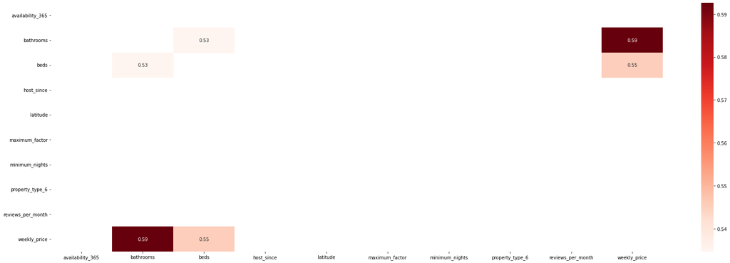

```python
dfCorr = train_estandarizado_cd.corr(method='pearson')
filteredDf = dfCorr[((dfCorr >= .5) | (dfCorr <= -.5)) & (dfCorr !=1.000)]
plt.figure(figsize=(30,10))
sns.heatmap(filteredDf, annot=True, cmap="Reds")
plt.show()
```

```python
from matplotlib.colors import ListedColormap
cm = plt.cm.RdBu
cm_bright = ListedColormap(['#FF0000', '#0000FF'])

corr_matrix = train_estandarizado_cd.corr().abs()

upper = corr_matrix.where(np.triu(np.ones(corr_matrix.shape), k=1).astype(np.bool))

pairs = np.where(upper>0.90)
fx = train_estandarizado_cd.columns[pairs[0]]
fy = train_estandarizado_cd.columns[pairs[1]]

i=1
plt.figure(figsize=(22,4))
for f1,f2 in zip(fx,fy):

    plt.subplot(1,5,i)

    plt.scatter(train_estandarizado_cd[f1],train_estandarizado_cd[f2],cmap=cm_bright, alpha=0.25)
    plt.xlabel(f1)
    plt.ylabel(f2)
    plt.grid()
    plt.tight_layout()

    i+=1

plt.show()
```

```python
clf = LogisticRegression(solver='newton-cg')
model_glm = clf.fit(train_estandarizado_cd, y_train_cd)
y_train_predicted = model_glm.predict_proba(train_estandarizado_cd)
```

Se observa que las variables más relevantes son el **mínimo de noches de forma fuerte y positiva** y el **precio semanal y latitude de manera fuerte y negativa**

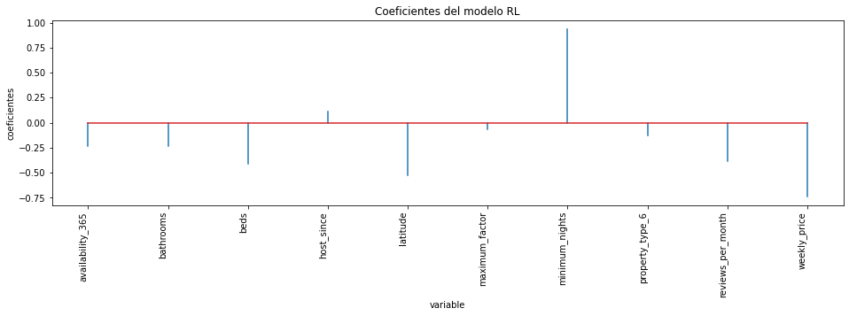

```python
df_coeficientes = pd.DataFrame(
                        {'predictor': import_vars_cd,
                         'coef': model_glm.coef_[0]})

fig, ax = plt.subplots(figsize=(16, 3.84))
ax.stem(df_coeficientes.predictor, df_coeficientes.coef, markerfmt=' ')
plt.xticks(rotation=90, ha='right', size=10)
ax.set_xlabel('variable')
ax.set_ylabel('coeficientes')
ax.set_title('Coeficientes del modelo RL');
```

Se va a calcular el error cuadrático medio y el R cuadrado que presenta la regresión logística para los apartamentos de corta duración:

Debido a su alto error cuadrático medio y a su bajo R-cuadrado en comparación con los modelos de Random Forest, la regresión no se considera como un buen modelo.

```python
predicciones_regre_cd = model_glm.predict(test_estandarizado_cd)
mse_reg_cd= mean_squared_error(predicciones_regre_cd, y_test_cd, squared=False)
r2_reg_cd = r2_score(y_test_cd.values.ravel(), predicciones_regre_cd)

tabla_resultados = tabla_resultados .append({'Modelo': 'Regresión Logística corta duración', 'RMSE': mse_reg_cd, 'R2': r2_reg_cd}, ignore_index=True)

print('Mean Squared Error:', round(mse_reg_cd, 4))
print('R-squared scores:', round(r2_reg_cd, 4))
```

```
Mean Squared Error: 62.6587
R-squared scores: 0.7882
```

```python
del model_glm
```

### Regresión logística LD

Para hacer la regresión logística de los apartamentos de larga duración hemos seleccionado los datos más relevantes que hemos hallado anteriormente con el Random Forest, y hemos visto la importancia, -coeficiente- que tienen estas variables para la regresión.

```python
train_estandarizado_ld =pd.DataFrame(StandardScaler().fit_transform(X_train_ld_1))
test_estandarizado_ld =pd.DataFrame(StandardScaler().fit_transform(X_test_ld_1))
nombres_columnas=X_train_ld_1.columns
train_estandarizado_ld.columns = nombres_columnas
nombres_columnas1=X_test_ld_1.columns
test_estandarizado_ld.columns = nombres_columnas1
```

[figure not shown]

```python
dfCorr = train_estandarizado_ld.corr(method ='pearson')
filteredDf = dfCorr[((dfCorr >= .5) | (dfCorr <= -.5)) & (dfCorr !=1.000)]
plt.figure(figsize=(30,10))
sns.heatmap(filteredDf, annot=True, cmap="Reds")
plt.show()
```

```python
from matplotlib.colors import ListedColormap
cm = plt.cm.RdBu
cm_bright = ListedColormap(['#FF0000', '#0000FF'])

corr_matrix = train_estandarizado_ld.corr().abs()

upper = corr_matrix.where(np.triu(np.ones(corr_matrix.shape), k=1).astype(np.bool))

pairs = np.where(upper>0.80)
fx = train_estandarizado_ld.columns[pairs[0]]
fy = train_estandarizado_ld.columns[pairs[1]]

i=1
plt.figure(figsize=(22,4))
for f1,f2 in zip(fx,fy):

    plt.subplot(1,5,i)

    plt.scatter(train_estandarizado_ld[f1],train_estandarizado_ld[f2],cmap=cm_bright, alpha=0.25)
    plt.xlabel(f1)
    plt.ylabel(f2)
    plt.grid()
    plt.tight_layout()

    i+=1

plt.show()
```

```python
clf = LogisticRegression(solver='newton-cg')
model_glm_ld = clf.fit(train_estandarizado_ld, y_train_ld)
y_train_predicted_ld = model_glm_ld.predict_proba(train_estandarizado_ld)
```

Se observa que las variables más relevantes son el **precio mensual, las camas y la disponibilidad anual de manera fuerte y negativa**

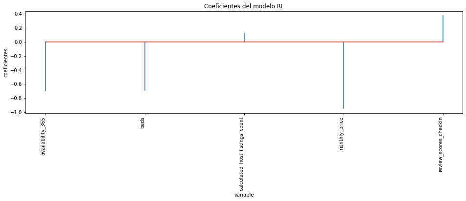

```python
df_coeficientes = pd.DataFrame(
                        {'predictor': train_estandarizado_ld.columns,
                         'coef': model_glm_ld.coef_[0]})

fig, ax = plt.subplots(figsize=(16, 3.84))
ax.stem(df_coeficientes.predictor, df_coeficientes.coef, markerfmt=' ')
plt.xticks(rotation=90, ha='right', size=10)
ax.set_xlabel('variable')
ax.set_ylabel('coeficientes')
ax.set_title('Coeficientes del modelo RL');
```

Se va a calcular el error cuadrático medio y el R cuadrado que presenta la regresión logística para los apartamentos de larga duración:

Debido a su alto error cuadrático medio y a su bajo R-cuadrado en comparación con los modelos de Random Forest, la regresión no se considera como un buen modelo.

```python
predicciones_regre_ld = model_glm_ld.predict(test_estandarizado_ld)
mse_reg_ld = mean_squared_error(predicciones_regre_ld, y_test_ld, squared=False)
r2_reg_ld = r2_score(y_test_ld.values.ravel(), predicciones_regre_ld)


tabla_resultados = tabla_resultados.append({'Modelo': 'Regresión Logística larga duración', 'RMSE': mse_reg_ld, 'R2': r2_reg_ld}, ignore_index=True)

print('Mean Squared Error:', round(mse_reg_ld, 4))
print('R-squared scores:', round(r2_reg_ld, 4))
```

```
Mean Squared Error: 70.2238
R-squared scores: 0.8465
```

```python
del model_glm_ld
```

### XGBoost CD

El modelo de XGBoost es muy similar al Random Forest ya que utiliza árboles de decisión, sin embargo se diferencia al poder crecer de manera más especializada en función de los datos.

```python
param_grid = {'n_estimators'  : [100],
              'max_features'  : ["auto"],
              'max_depth'     : [2],
              'learning_rate' : [0.1]
             }
```

```python
from sklearn.model_selection import RepeatedKFold
grid_cd_b = GridSearchCV(
        estimator  = GradientBoostingRegressor(random_state=123),
        param_grid = param_grid,
        n_jobs     = multiprocessing.cpu_count() - 1,
        cv         = RepeatedKFold(n_splits=3, n_repeats=1, random_state=123),
        refit      = True,
        verbose    = 0,
        return_train_score = True
       )

grid_cd_b.fit(X = X_train_cd_1, y = y_train_cd)
# 2 100 0.1
```

```
GridSearchCV(cv=RepeatedKFold(n_repeats=1, n_splits=3, random_state=123),
             estimator=GradientBoostingRegressor(random_state=123), n_jobs=1,
             param_grid={'learning_rate': [0.1], 'max_depth': [2],
                         'max_features': ['auto'], 'n_estimators': [100]},
             return_train_score=True)
```

```python
resultados = pd.DataFrame(grid_cd_b.cv_results_)
resultados.filter(regex = '(param*|mean_t|std_t)') \
    .drop(columns = 'params') \
    .sort_values('mean_test_score', ascending = False) \
    .head(4)
```

|  | param_learning_rate | param_max_depth | param_max_features | param_n_estimators | mean_test_score | std_test_score | mean_train_score | std_train_score |
| --- | --- | --- | --- | --- | --- | --- | --- | --- |
| 0 | 0.1 | 2 | auto | 100 | 0.952574 | 0.024714 | 0.985764 | 0.002497 |

```python
grid_cd_b.best_estimator_
```

```
GradientBoostingRegressor(max_depth=2, max_features='auto', random_state=123)
```

Se va a calcular el error cuadrático medio y el R cuadrado que presenta el XG Boost para los apartamentos de corta duración:

- **Error cuadrático medio:** Mide el error cuadrado promedio de nuestras predicciones. Para cada punto, calcula la diferencia cuadrada entre las predicciones y el objetivo y luego promedia esos valores. La raíz cuadrada del error cuadrático medio de este modelo es de 21,98 unidades monetarias, por lo que es un error bajo y por tanto, un buen modelo.
- **R-cuadrado:** Indica la aptitud del modelo. Muestra que también las variables independientes seleccionadas explican la variabilidad en sus variables dependiente. El modelo explica un 97,39% de lo que se quiere explicar.

```python
predicciones_boost_cd = grid_cd_b.predict(X_test_cd_1)
mean_squared_error_boost_cd = mean_squared_error(predicciones_boost_cd, y_test_cd, squared=False)
r2_boost_cd = r2_score(y_test_cd.values.ravel(), predicciones_boost_cd)


tabla_resultados = tabla_resultados.append({'Modelo': 'XGBoost corta duración', 'RMSE': mean_squared_error_boost_cd, 'R2': r2_boost_cd}, ignore_index=True)

print('Mean Squared Error:', round(mean_squared_error_boost_cd, 4))
print('R-squared scores:', round(r2_boost_cd, 4))
```

```
Mean Squared Error: 21.984
R-squared scores: 0.9739
```

```python
del predicciones_boost_cd
```

### XGBoost LD

El modelo de XGBoost es muy similar al Random Forest ya que utiliza árboles de decisión, sin embargo se diferencia al poder crecer de manera más especializada en función de los datos.

```python
param_grid = {'n_estimators'  : [70],
              'max_features'  : ["auto"],
              'max_depth'     : [4],
              'learning_rate' : [0.08]
             }
#  4 70 0.08
```

```python
from sklearn.model_selection import RepeatedKFold
grid_ld_b = GridSearchCV(
        estimator  = GradientBoostingRegressor(random_state=123),
        param_grid = param_grid,
        n_jobs     = multiprocessing.cpu_count() - 1,
        cv         = RepeatedKFold(n_splits=3, n_repeats=1, random_state=123),
        refit      = True,
        verbose    = 0,
        return_train_score = True
       )

grid_ld_b.fit(X = X_train_ld_1, y = y_train_ld)
```

```
GridSearchCV(cv=RepeatedKFold(n_repeats=1, n_splits=3, random_state=123),
             estimator=GradientBoostingRegressor(random_state=123), n_jobs=1,
             param_grid={'learning_rate': [0.08], 'max_depth': [4],
                         'max_features': ['auto'], 'n_estimators': [70]},
             return_train_score=True)
```

```python
resultados = pd.DataFrame(grid_ld_b.cv_results_)
resultados.filter(regex = '(param*|mean_t|std_t)') \
    .drop(columns = 'params') \
    .sort_values('mean_test_score', ascending = False) \
    .head(4)
```

|  | param_learning_rate | param_max_depth | param_max_features | param_n_estimators | mean_test_score | std_test_score | mean_train_score | std_train_score |
| --- | --- | --- | --- | --- | --- | --- | --- | --- |
| 0 | 0.08 | 4 | auto | 70 | 0.817163 | 0.207026 | 0.994056 | 0.002653 |

```python
grid_ld_b.best_estimator_
```

```
GradientBoostingRegressor(learning_rate=0.08, max_depth=4, max_features='auto',
                          n_estimators=70, random_state=123)
```

Se va a calcular el error cuadrático medio y el R cuadrado que presenta el XGBoost para los apartamentos de larga duración:

- **Error cuadrático medio:** Mide el error cuadrado promedio de nuestras predicciones. Para cada punto, calcula la diferencia cuadrada entre las predicciones y el objetivo y luego promedia esos valores. La raíz cuadrada del error cuadrático medio de este modelo es de 32,5 unidades monetarias, por lo que es un error bajo y por tanto, un buen modelo.
- **R-cuadrado:** Indica la aptitud del modelo. Muestra que también las variables independientes seleccionadas explican la variabilidad en sus variables dependiente. El modelo explica un 84,65% de lo que se quiere explicar.

```python
predicciones_boost_ld = grid_ld_b.predict(X_test_ld_1)
mean_squared_error_boost_ld = mean_squared_error(predicciones_boost_ld, y_test_ld, squared=False)
r2_boost_ld = r2_score(y_test_ld.values.ravel(), predicciones_regre_ld)

tabla_resultados = tabla_resultados.append({'Modelo': 'XGBoost larga duración', 'RMSE': mean_squared_error_boost_ld, 'R2': r2_boost_ld}, ignore_index=True)

print('Mean Squared Error:', round(mean_squared_error_boost_ld, 4))
print('R-squared scores:', round(r2_boost_ld, 4))
```

```
Mean Squared Error: 32.501
R-squared scores: 0.8465
```

```python
del predicciones_boost_ld
```

### SVM CD

Se va a calcular el **error cuadrático medio y R-cuadrado** que presenta el Support Vector Machine para los apartamentos de corta duración:

Se ha empleado el **kernel gaussiano, el polinómico y sigmoid**, respecto al resto de modelos, el SVM presenta unos resultados poco favorables. Su alto error cuadrático medio y su bajo R-cuadrado demuestra que no se considera como un buen modelo.

```python
from sklearn import svm
regr = svm.SVR(kernel = "rbf")
regr.fit(X_train_cd_1, y_train_cd)
prediction_cd_SVM = regr.predict(X_test_cd_1)
mean_squared_error_SVM_cd = mean_squared_error(prediction_cd_SVM, y_test_cd, squared=False)
r2_SVM_cd = r2_score(y_test_cd.values.ravel(), prediction_cd_SVM)

print('Mean Squared Error:', round(mean_squared_error_SVM_cd, 4))
print('R-squared scores:', round(r2_SVM_cd, 4))
```

```
Mean Squared Error: 88.6827
R-squared scores: 0.5757
```

```python
del regr
```

```python
from sklearn import svm
regr = svm.SVR(kernel = "poly")
regr.fit(X_train_cd_1, y_train_cd)
prediction_cd_SVM = regr.predict(X_test_cd_1)
mean_squared_error_SVM_cd = mean_squared_error(prediction_cd_SVM, y_test_cd, squared=False)
r2_SVM_cd= r2_score(y_test_cd.values.ravel(), prediction_cd_SVM)

tabla_resultados = tabla_resultados.append({'Modelo': 'SVM poly corta duración', 'RMSE': mean_squared_error_SVM_cd, 'R2': r2_SVM_cd}, ignore_index=True)

print('Mean Squared Error:', round(mean_squared_error_SVM_cd, 4))
print('R-squared scores:', round(r2_SVM_cd, 4))
```

```
Mean Squared Error: 53.1902
R-squared scores: 0.8474
```

```python
del regr
```

```python
from sklearn import svm
regr = svm.SVR(kernel = "sigmoid")
regr.fit(X_train_cd_1, y_train_cd)
prediction_cd_SVM = regr.predict(X_test_cd_1)
mean_squared_error_SVM_cd = mean_squared_error(prediction_cd_SVM, y_test_cd, squared=False)
r2_SVM_cd = r2_score(y_test_cd.values.ravel(), prediction_cd_SVM)

print('Mean Squared Error:', round(mean_squared_error_SVM_cd, 4))
print('R-squared scores:', round(r2_SVM_cd, 4))
```

```
Mean Squared Error: 124.809
R-squared scores: 0.1596
```

```python
del regr
```

### SVM LD

Se ha empleado el **kernel gaussiano, el polinómico y sigmoid**, y respecto al resto de modelos, el SVM presenta unos resultados poco favorables. Su alto error cuadrático medio y su bajo R-cuadrado demuestra que no se considera como un buen modelo.

El polinómico, pese a dar un error muy alto y un R-cuadrado muy bajo es el kernel que mejor da en comparación con los demás. Nos indica cuál es la estructura de nuestros datos de cara a hacer la red neuronal.

```python
from sklearn import svm
regr = svm.SVR(kernel = "rbf")
regr.fit(X_train_ld_1, y_train_ld)
prediction_ld_SVM = regr.predict(X_test_ld_1)
mean_squared_error_SVM_ld= mean_squared_error(prediction_ld_SVM, y_test_ld, squared=False)
r2_SVM_ld = r2_score(y_test_ld.values.ravel(), prediction_ld_SVM)

print('Mean Squared Error:', round(mean_squared_error_SVM_ld, 4))
print('R-squared scores:', round(r2_SVM_ld, 4))
```

```
Mean Squared Error: 144.1514
R-squared scores: 0.353
```

```python
del regr
```

```python
from sklearn import svm
regr = svm.SVR(kernel = "poly")
regr.fit(X_train_ld_1, y_train_ld)
prediction_ld_SVM = regr.predict(X_test_ld_1)
mean_squared_error_SVM_ld= mean_squared_error(prediction_ld_SVM, y_test_ld, squared=False)
r2_SVM_ld = r2_score(y_test_ld.values.ravel(), prediction_ld_SVM)

tabla_resultados = tabla_resultados.append({'Modelo': 'SVM poly larga duración', 'RMSE': mean_squared_error_SVM_ld, 'R2': r2_SVM_ld}, ignore_index=True)

print('Mean Squared Error:', round(mean_squared_error_SVM_ld, 4))
print('R-squared scores:', round(r2_SVM_ld, 4))
```

```
Mean Squared Error: 141.8374
R-squared scores: 0.3736
```

```python
del regr
```

```python
from sklearn import svm
regr = svm.SVR(kernel = "sigmoid")
regr.fit(X_train_ld_1, y_train_ld)
prediction_ld_SVM = regr.predict(X_test_ld_1)
mean_squared_error_SVM_ld= mean_squared_error(prediction_ld_SVM, y_test_ld, squared=False)
r2_SVM_ld = r2_score(y_test_ld.values.ravel(), prediction_ld_SVM)

print('Mean Squared Error:', round(mean_squared_error_SVM_ld, 4))
print('R-squared scores:', round(r2_SVM_ld, 4))
```

```
Mean Squared Error: 182.2608
R-squared scores: -0.0343
```

```python
del regr
```

## Redes Neuronales

A continuación vamos a realizar dos redes neuronales entrenadas sobre los datos de corta y larga duración, como hemos ido haciendo con el resto de modelos.

Primero vamos a estandarizar los datos para después generar una red neuronal con distintas capas en función de la estructura de los mismos. Para seleccionar el óptimo de capas nos hemos guiado por la lógica y la teoría aprendida en clase.

Sin embargo, para seleccionar la función de activación óptima hemos seguido esta [publicación](https://towardsdatascience.com/fantastic-activation-functions-and-when-to-use-them-481fe2bb2bde).

Nos hemos dado cuenta que de todas las funciones de activación disponibles en la **librería Keras** aquellas basadas en una distribución exponencial son las que mejor se adaptan a la composición de nuestros datos. Por ello, hemos repetido el proceso con las funciones de activación Elu, Selu y **Gelu** quedandonos con esta última para la estructura de nuestros datos.

Por último, para seleccionar el mejor optimizador hemos utilizado aquellos disponibles en esta [web](https://keras.io/api/optimizers/).

Finalmente nos hemos quedado con Adam Max frente a Adam, que es el que vimos en clase por defecto.

### Corta duración

```python
from sklearn.pipeline import Pipeline
import tensorflow as tf
from tensorflow.keras import layers
import datetime

%load_ext tensorboard
```

```python
scaler = StandardScaler()


train_cd_escal_prov = scaler.fit(X_train_cd_1)
train_estandarizado_cd = pd.DataFrame(scaler.transform(X_train_cd_1))



test_cd_escal_prov = scaler.fit(X_test_cd_1)
test_estandarizado_cd = pd.DataFrame(scaler.transform(X_test_cd_1))


nombres_columnas= X_train_cd_1.columns
train_estandarizado_cd.columns = nombres_columnas
nombres_columnas1=X_test_cd_1.columns
test_estandarizado_cd.columns = nombres_columnas1
```

```python
inputs = tf.keras.Input(shape=(train_estandarizado_cd.shape[1],))
x = tf.keras.layers.Dense(144, activation="gelu")(inputs)
x = tf.keras.layers.Dropout(0.2)(x)
x = tf.keras.layers.Dense(144, activation="gelu")(x)
x = tf.keras.layers.Dropout(0.2)(x)
x = tf.keras.layers.Dense(64, activation="gelu")(x)
x = tf.keras.layers.Dropout(0.2)(x)
x = tf.keras.layers.Dense(64, activation="gelu")(x)
x = tf.keras.layers.Dropout(0.2)(x)
x = tf.keras.layers.Dense(24, activation="gelu")(x)
x = tf.keras.layers.Dropout(0.2)(x)
x = tf.keras.layers.Dense(24, activation="gelu")(x)
x = tf.keras.layers.Dropout(0.2)(x)
x = tf.keras.layers.Dense(8, activation="gelu")(x)
x = tf.keras.layers.Dropout(0.2)(x)
output = tf.keras.layers.Dense(1)(x)
model = tf.keras.Model(inputs, output)

## RMSE exponenciales
## 53: elu, Adam, 0.0001
## 30: selu, Adam, 0.0001
## 32: gelu, Adam, 0.0001
## 30: gelu, Adamax, 0.0001
```

```python
log_dir = "logs/fit/" + datetime.datetime.now().strftime("%Y%m%d-%H%M%S")
tensorboard_callback = tf.keras.callbacks.TensorBoard(log_dir=log_dir, histogram_freq=1)
```

```python
model.compile(optimizer=tf.keras.optimizers.Adamax(learning_rate=0.001),
              loss=tf.keras.losses.MeanSquaredError(),
              metrics=tf.keras.metrics.RootMeanSquaredError(name='rmse'))
```

```python
model.fit(train_estandarizado_cd.to_numpy(),
          y_train_cd.to_numpy(),
          epochs=100,
          validation_data=(test_estandarizado_cd.to_numpy(),y_test_cd.to_numpy()),
          callbacks=[tensorboard_callback])
```

```
<keras.callbacks.History at 0x7f4ef47a0e50>
```

```python
%tensorboard --logdir logs/fit
```

Se va a calcular el error cuadrático medio y el R cuadrado que presentan las redes neuronales para los apartamentos de corta duración:

```python
predicted_data_norm = test_estandarizado_cd.copy()
pred_price_cd = model.predict(test_estandarizado_cd.to_numpy())
predicted_data_unorm = pd.DataFrame(index=predicted_data_norm.index, columns=predicted_data_norm.columns, data=test_cd_escal_prov.inverse_transform(test_estandarizado_cd))
mse_cd = mean_squared_error(pred_price_cd, y_test_cd, squared=False)
r2_cd = r2_score(y_test_cd.values.ravel(), pred_price_cd)

tabla_resultados = tabla_resultados.append({'Modelo': 'Red Neuronal corta duración', 'RMSE': mse_cd, 'R2': r2_cd}, ignore_index=True)

print('Mean Squared Error:', round(mse_cd, 4))
print('R-squared scores:', round(r2_cd, 4))
```

```
Mean Squared Error: 39.0924
R-squared scores: 0.9176
```

```python
model.summary()
```

```
Model: "model"
_________________________________________________________________
 Layer (type)                Output Shape              Param #
=================================================================
 input_1 (InputLayer)        [(None, 10)]              0

 dense (Dense)               (None, 144)               1584

 dropout (Dropout)           (None, 144)               0

 dense_1 (Dense)             (None, 144)               20880

 dropout_1 (Dropout)         (None, 144)               0

 dense_2 (Dense)             (None, 64)                9280

 dropout_2 (Dropout)         (None, 64)                0

 dense_3 (Dense)             (None, 64)                4160

 dropout_3 (Dropout)         (None, 64)                0

 dense_4 (Dense)             (None, 24)                1560

 dropout_4 (Dropout)         (None, 24)                0

 dense_5 (Dense)             (None, 24)                600

 dropout_5 (Dropout)         (None, 24)                0

 dense_6 (Dense)             (None, 8)                 200

 dropout_6 (Dropout)         (None, 8)                 0

 dense_7 (Dense)             (None, 1)                 9

=================================================================
Total params: 38,273
Trainable params: 38,273
Non-trainable params: 0
_________________________________________________________________
```

### Larga duración

```python
scaler = StandardScaler()


train_ld_escal_prov = scaler.fit(X_train_ld_1)
train_estandarizado_ld = pd.DataFrame(scaler.transform(X_train_ld_1))



test_ld_escal_prov = scaler.fit(X_test_ld_1)
test_estandarizado_ld = pd.DataFrame(scaler.transform(X_test_ld_1))


nombres_columnas= X_train_ld_1.columns
train_estandarizado_ld.columns = nombres_columnas
nombres_columnas1=X_test_ld_1.columns
test_estandarizado_ld.columns = nombres_columnas1
```

```python
inputs_ld = tf.keras.Input(shape=(train_estandarizado_ld.shape[1],))
x = tf.keras.layers.Dense(254, activation="gelu")(inputs_ld)
x = tf.keras.layers.Dropout(0.2)(x)
x = tf.keras.layers.Dense(254, activation="gelu")(x)
x = tf.keras.layers.Dropout(0.2)(x)
x = tf.keras.layers.Dense(144, activation="gelu")(x)
x = tf.keras.layers.Dropout(0.2)(x)
x = tf.keras.layers.Dense(144, activation="gelu")(x)
x = tf.keras.layers.Dropout(0.2)(x)
x = tf.keras.layers.Dense(64, activation="gelu")(x)
x = tf.keras.layers.Dropout(0.2)(x)
x = tf.keras.layers.Dense(64, activation="gelu")(x)
x = tf.keras.layers.Dropout(0.2)(x)
x = tf.keras.layers.Dense(24, activation="gelu")(x)
x = tf.keras.layers.Dropout(0.2)(x)
x = tf.keras.layers.Dense(24, activation="gelu")(x)
x = tf.keras.layers.Dropout(0.2)(x)
x = tf.keras.layers.Dense(8, activation="gelu")(x)
x = tf.keras.layers.Dropout(0.2)(x)
output_ld = tf.keras.layers.Dense(1)(x)
model_ld = tf.keras.Model(inputs_ld, output_ld)
```

```python
log_dir = "logs/fit/" + datetime.datetime.now().strftime("%Y%m%d-%H%M%S")
tensorboard_callback = tf.keras.callbacks.TensorBoard(log_dir=log_dir, histogram_freq=1)
```

```python
model_ld.compile(optimizer=tf.keras.optimizers.Adamax(learning_rate=0.001),
              loss=tf.keras.losses.MeanSquaredError(),
              metrics=tf.keras.metrics.RootMeanSquaredError(name='rmse'))
```

```python
model_ld.fit(train_estandarizado_ld.to_numpy(),
          y_train_ld.to_numpy(),
          epochs=100,
          validation_data=(test_estandarizado_ld.to_numpy(),y_test_ld.to_numpy()),
          callbacks=[tensorboard_callback])
```

```
<keras.callbacks.History at 0x7f4ef4690a90>
```

```python
%tensorboard --logdir logs/fit
```

```
Reusing TensorBoard on port 6006 (pid 672), started 0:00:58 ago. (Use '!kill 672' to kill it.)
```

Se va a calcular el error cuadrático medio y el R cuadrado que presentan las redes neuronales para los apartamentos de larga duración:

```python
predicted_data_norm_ld = test_estandarizado_ld.copy()
pred_price_ld = model_ld.predict(test_estandarizado_ld.to_numpy())
predicted_data_unorm_ld = pd.DataFrame(index=predicted_data_norm_ld.index, columns=predicted_data_norm_ld.columns, data=test_ld_escal_prov.inverse_transform(test_estandarizado_ld))
mse_ld = mean_squared_error(pred_price_ld, y_test_ld, squared=False)
r2_ld = r2_score(y_test_ld.values.ravel(), pred_price_ld)

tabla_resultados = tabla_resultados.append({'Modelo': 'Red Neuronal larga duración', 'RMSE': mse_ld, 'R2': r2_ld}, ignore_index=True)

print('Mean Squared Error:', round(mse_ld, 4))
print('R-squared scores:', round(r2_ld, 4))
```

```
Mean Squared Error: 32.4796
R-squared scores: 0.9672
```

```python
model_ld.summary()
```

```
Model: "model_1"
_________________________________________________________________
 Layer (type)                Output Shape              Param #
=================================================================
 input_2 (InputLayer)        [(None, 5)]               0

 dense_8 (Dense)             (None, 254)               1524

 dropout_7 (Dropout)         (None, 254)               0

 dense_9 (Dense)             (None, 254)               64770

 dropout_8 (Dropout)         (None, 254)               0

 dense_10 (Dense)            (None, 144)               36720

 dropout_9 (Dropout)         (None, 144)               0

 dense_11 (Dense)            (None, 144)               20880

 dropout_10 (Dropout)        (None, 144)               0

 dense_12 (Dense)            (None, 64)                9280

 dropout_11 (Dropout)        (None, 64)                0

 dense_13 (Dense)            (None, 64)                4160

 dropout_12 (Dropout)        (None, 64)                0

 dense_14 (Dense)            (None, 24)                1560

 dropout_13 (Dropout)        (None, 24)                0

 dense_15 (Dense)            (None, 24)                600

 dropout_14 (Dropout)        (None, 24)                0

 dense_16 (Dense)            (None, 8)                 200

 dropout_15 (Dropout)        (None, 8)                 0

 dense_17 (Dense)            (None, 1)                 9

=================================================================
Total params: 139,703
Trainable params: 139,703
Non-trainable params: 0
_________________________________________________________________
```

No obstante, vamos a mostrar la tabla que indica todos los modelos con sus errores cuadráticos medios y R-cuadrados correspondientes.

```python
tabla_resultados = tabla_resultados.set_index("Modelo")
tabla_resultados
```

| Modelo | RMSE | R2 |
| --- | --- | --- |
| Random Forest corta duración inicial | 21.993893 | 0.973903 |
| Random Forest larga duración inicial | 20.753872 | 0.986590 |
| Random Forest corta duración final | 21.260027 | 0.975616 |
| Random Forest larga duración final | 20.976073 | 0.986301 |
| Regresión Logística corta duración | 62.658731 | 0.788191 |
| Regresión Logística larga duración | 70.223776 | 0.846464 |
| XGBoost corta duración | 21.984043 | 0.973927 |
| XGBoost larga duración | 32.501039 | 0.846464 |
| SVM poly corta duración | 53.190214 | 0.847368 |
| SVM poly larga duración | 141.837419 | 0.373642 |
| Red Neuronal corta duración | 39.092416 | 0.917555 |
| Red Neuronal larga duración | 32.479573 | 0.967156 |

## **UBICACIÓN DE LOS APARTAMENTOS DE AIRBNB**

Nos ha parecido interesante descubrir las zonas donde la variable objetivo tiene más notabilidad, es decir, las zonas del mapa de Canada donde los Airbnb tienen un precio más elevado.

Por ello, hemos creado dos mapas, -porque la distribución de pisos de corta y larga duración es distinta, en función de las zonas- donde nos muestre las calles con los apartamentos más caros representados por un color más fuerte.

Hemos observado que los precios más caros, -especialmente los de corta duración por ser destino turístico vacacional- se encuentran cerca del litoral.

Además, se comprueba que estamos acertados debido a la [publicación](https://www.expansion.com/directivos/estilo-vida/casas/2018/07/13/5b488c51268e3eec7f8b45a3.html) que muestra que los precios más caros se encuentran en el *skyline de la bahía.*

## CORTA DURACIÓN

```python
def Mapa_Maria(X_data, y_data):
  longs_cd = X_data['longitude']
  lats_cd = X_data['latitude']

  centro_gravedad_cd = {}
  centro_gravedad_cd['longs_cd'] = np.dot(longs_cd, y_data)
  centro_gravedad_cd['lats_cd'] = np.dot(lats_cd, y_data)

  print(centro_gravedad_cd)

  mediaLong_cd = statistics.mean(longs_cd)
  mediaLat_cd = statistics.mean(lats_cd)

  mapa_cd = folium.Map(location=[mediaLat_cd, mediaLong_cd], zoom_start = 13)

  mapa_calor_cd = HeatMap( list(zip(lats_cd, longs_cd, y_data)),
                    min_opacity=0.2,
                    max_val=y_data.max(),
                    radius=50,
                    blur=50,
                    max_zoom=1)

  tooltip = 'Centro de gravedad'
  folium.Marker([centro_gravedad_cd['lats_cd'], centro_gravedad_cd['longs_cd']], popup="Centro", tooltip = tooltip).add_to(mapa_cd)

  mapa_calor_cd.add_to(mapa_cd)
  return mapa_cd
```

```python
Mapa_Maria(validation_cd, y_validation_cd)
```

```
{'longs_cd': -3934142.3802083004, 'lats_cd': 1574182.1818133597}
```

Make this Notebook Trusted to load map: File -> Trust Notebook

[interactive chart not shown]

## LARGA DURACIÓN

```python
Mapa_Maria(validation_ld, y_validation_ld)
```

```
{'longs_cd': -4397562.6539768, 'lats_cd': 1759426.8279582502}
```

Make this Notebook Trusted to load map: File -> Trust Notebook

[interactive chart not shown]

## **MAPA DE UBICACIONES RESPECTO A LOS MODELOS RANDOM FOREST Y REDES NEURONALES**

```python
predicciones_RF_cd = modelo_final_cd_1.predict(X_validation_cd_1)
```

```python
predicciones_RF_ld = modelo_final_ld_1.predict(X_validation_ld_1)
```

```python
scaler = StandardScaler()


validation_cd_escal_prov = scaler.fit(X_validation_cd_1)
validation_estandarizado_cd = pd.DataFrame(scaler.transform(X_validation_cd_1))



validation_ld_escal_prov = scaler.fit(X_validation_ld_1)
validation_estandarizado_ld = pd.DataFrame(scaler.transform(X_validation_ld_1))


nombres_columnas= X_validation_cd_1.columns
validation_estandarizado_cd.columns = nombres_columnas
nombres_columnas1=X_validation_ld_1.columns
validation_estandarizado_ld.columns = nombres_columnas1
```

```python
pred_price_cd = model.predict(validation_estandarizado_cd.to_numpy())
pred_price_ld = model_ld.predict(validation_estandarizado_ld.to_numpy())
```

## RF CORTA DURACIÓN

```python
Mapa_Maria(validation_cd, predicciones_RF_cd)
```

```
{'longs_cd': -3879763.0749806254, 'lats_cd': 1552439.9042256435}
```

Make this Notebook Trusted to load map: File -> Trust Notebook

[interactive chart not shown]

## RF LARGA DURACIÓN

```python
Mapa_Maria(validation_ld, predicciones_RF_ld)
```

```
{'longs_cd': -4435855.874265896, 'lats_cd': 1774762.8971898404}
```

Make this Notebook Trusted to load map: File -> Trust Notebook

[interactive chart not shown]

## CORTA DURACIÓN

```python
Mapa_Maria(validation_cd, np.concatenate(pred_price_cd, axis=0 ))
```

```
{'longs_cd': -3209939.7799616917, 'lats_cd': 1284411.519053117}
```

Make this Notebook Trusted to load map: File -> Trust Notebook

[interactive chart not shown]

## LARGA DURACIÓN

```python
Mapa_Maria(validation_ld, np.concatenate(pred_price_ld, axis=0 ))
```

```
{'longs_cd': -4233747.0931474, 'lats_cd': 1693868.3569663577}
```

Make this Notebook Trusted to load map: File -> Trust Notebook

[interactive chart not shown]